# Univariate TS Models (ARIMA/SARIMA)s

Published

October 2, 2025

The differencing and ADF stationarity tests were completed in the EDA section to ensure that all time series achieved stationarity before modeling. In this stage, I focus on examining the ACF and PACF plots of the stationary series to identify potential autoregressive and moving average components.

The ARIMA and SARIMA analyses are integrated in this step. By inspecting both ACF and PACF patterns, I determine whether each series exhibits seasonal behavior and select appropriate model orders accordingly. The final model for each variable is chosen based on diagnostic results and goodness-of-fit criteria, ensuring suitability for further time-series forecasting and causal analysis.

# Brief Introduction

ARIMA Model: ARIMA (AutoRegressive Integrated Moving Average) is used for non-seasonal time series data that exhibit patterns over time. The parameters are: - p: The order of the autoregressive (AR) term. - d: The degree of differencing to make the series stationary. - q: The order of the moving average (MA) term.

SARIMA Model: SARIMA (Seasonal ARIMA) is an extension of the ARIMA model that deals with seasonality in time series data. The additional parameters for seasonal components are: - P: The order of the seasonal autoregressive (AR) term. - D: The degree of seasonal differencing. - Q: The order of the seasonal moving average (MA) term. - s: The number of periods in each season.

**Data and Model Selection**

In the EDA phase, we performed differencing and seasonal differencing to transform the original series into stationary series. The stationarity of the differenced series was validated using the ADF test. Therefore, we can now decide whether to apply the ARIMA or SARIMA model and select the appropriate values for d or D.

# ACF and PACF Plots

```r
# load data
library(readr)
library(dplyr)
library(lubridate)
library(plotly)
library(ggplot2)
raw <- read.csv("data-raw/la_teu_data.csv", stringsAsFactors = FALSE)

num_cols <- c("Loaded_Imports","Empty_Imports","Total_Imports",
              "Loaded_Exports","Empty_Exports","Total_Exports","Total_TEUs")

Sys.setlocale("LC_TIME", "C")
```

```
[1] "C"
```

```r
la_teu <- raw %>%
  mutate(
    Date = my(Date),
    across(all_of(num_cols), ~ as.numeric(gsub(",", "", .))),
    Prior_Year_Change = suppressWarnings(as.numeric(sub("%","", Prior_Year_Change))) / 100,
    Empty_Containers = Empty_Imports + Empty_Exports,
    Total_calc = Loaded_Imports + Loaded_Exports + Empty_Containers,
    Total_TEUs = ifelse(is.na(Total_TEUs), Total_calc, Total_TEUs)
  ) %>%
  arrange(Date) %>%
  filter(Date >= as.Date("2000-01-01"))

brent <- read_csv("data-raw/brent.csv", show_col_types = FALSE)
WTI   <- read_csv("data-raw/WTI.csv", show_col_types = FALSE)
usd   <- read_csv("data-raw/usd.csv", show_col_types = FALSE)
rmb   <- read_csv("data-raw/rmb.csv", show_col_types = FALSE)

brent <- brent %>%
  rename(Date = observation_date, Price = MCOILBRENTEU)
usd <- usd %>%
  rename(Date = observation_date, Index = DTWEXBGS)

gscpi <- read_csv(
  "data-raw/GSCPI.csv",
  col_types = cols(
    Date  = col_date(format = "%d-%b-%Y"),  # 31-Jan-1998
    GSCPI = col_double()
  ),
  show_col_types = FALSE
) %>%
  mutate(Date = floor_date(Date, "month")) %>%
  filter(Date >= as.Date("2000-01-01"))

ahs_y <- read_csv("data-raw/ahs.csv", show_col_types = FALSE) %>%
  rename(
    Year = Date,
    Tariff = `AHS Weighted Average (%)`
  ) %>%
  filter(Year >= 2000, Year <= 2022)

sp500 <- read_csv("data-raw/sp500.csv") %>%
  mutate(Date = as.Date(observation_date)) %>%
  filter(Date >= as.Date("2015-10-01") & Date <= as.Date("2024-12-01")) %>%
  mutate(Year = year(Date), Month = month(Date)) %>%
  group_by(Year, Month) %>%
  slice_max(Date) %>%
  ungroup() %>%
  mutate(YearMonth = as.Date(paste0(Year, "-", Month, "-01"))) %>%
  select(YearMonth, SP500)
sp500_clean <- sp500 %>%
  filter(!is.na(SP500))

rsafs<- read_csv("data-raw/RSAFS.csv")
rsafs <- rsafs%>%
  mutate(Date = as.Date(observation_date)) %>%
  select(Date, RSAFS)

la_teu_ts <- ts(la_teu$Total_TEUs, start = c(2000, 1), frequency = 12)
la_li_ts <- ts(la_teu$Loaded_Imports, start = c(2000, 1), frequency = 12)
la_le_ts <- ts(la_teu$Loaded_Exports, start = c(2000, 1), frequency = 12)
brent_ts <- ts(brent$Price, start = c(2000, 1), frequency = 12)
usd_ts <- ts(usd$Index, start = c(2000, 1), frequency = 12)
gscpi_ts <- ts(gscpi$GSCPI, start = c(2000, 1), frequency = 12)
ahs_ts <- ts(ahs_y$Tariff, start = min(ahs_y$Year), frequency = 1)
sp500_ts <- ts(sp500_clean$SP500, start = c(2000, 1), frequency = 12)
rsafs_ts <- ts(rsafs$RSAFS, start = c(2000, 1), frequency = 12)
```

**Total TEUs**

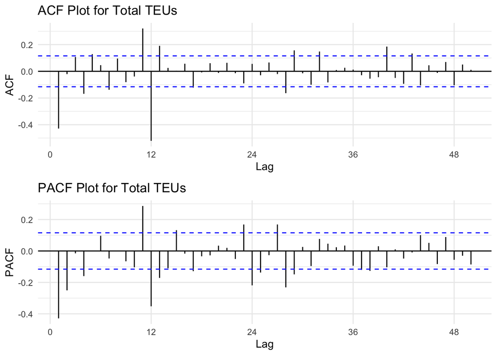

```r
library(gridExtra)
library(forecast)
library(ggplot2)

facf1 <- ggAcf(diff(diff(la_teu_ts, lag = 12)), lag.max = 50) +
  ggtitle("ACF Plot for Total TEUs") +
  theme_minimal()

fpacf1 <- ggPacf(diff(diff(la_teu_ts, lag = 12)), lag.max = 50) +
  ggtitle("PACF Plot for Total TEUs") +
  theme_minimal()

grid.arrange(facf1, fpacf1, nrow = 2)
```

**Loaded Imports**

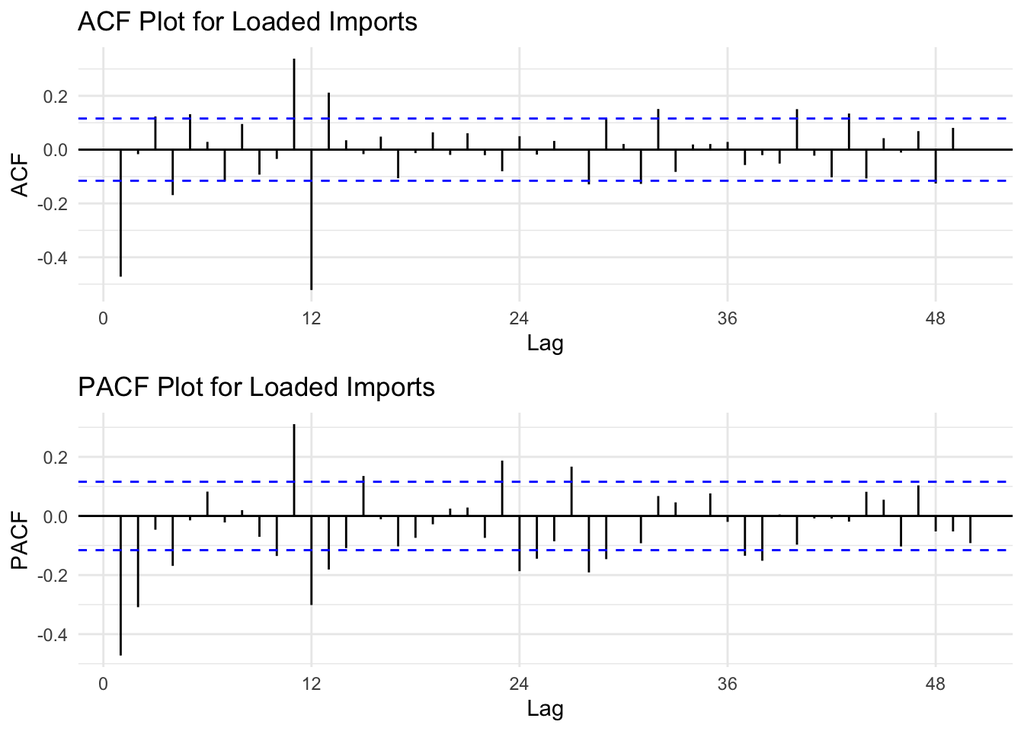

```r
facf2 <- ggAcf(diff(diff(la_li_ts, lag = 12)), lag.max = 50) +
  ggtitle("ACF Plot for Loaded Imports") +
  theme_minimal()

fpacf2 <- ggPacf(diff(diff(la_li_ts, lag = 12)), lag.max = 50) +
  ggtitle("PACF Plot for Loaded Imports") +
  theme_minimal()

grid.arrange(facf2, fpacf2, nrow = 2)
```

**Loaded Exports**

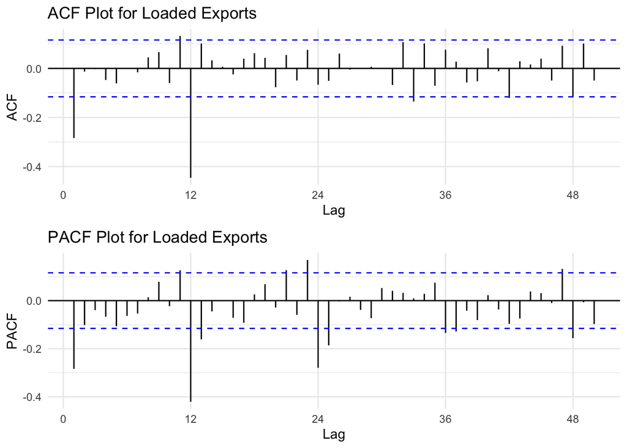

```r
facf3 <- ggAcf(diff(diff(la_le_ts, lag = 12)), lag.max = 50) +
  ggtitle("ACF Plot for Loaded Exports") +
  theme_minimal()

fpacf3 <- ggPacf(diff(diff(la_le_ts, lag = 12)), lag.max = 50) +
  ggtitle("PACF Plot for Loaded Exports") +
  theme_minimal()

grid.arrange(facf3, fpacf3, nrow = 2)
```

**Brent Crude Oil Price**

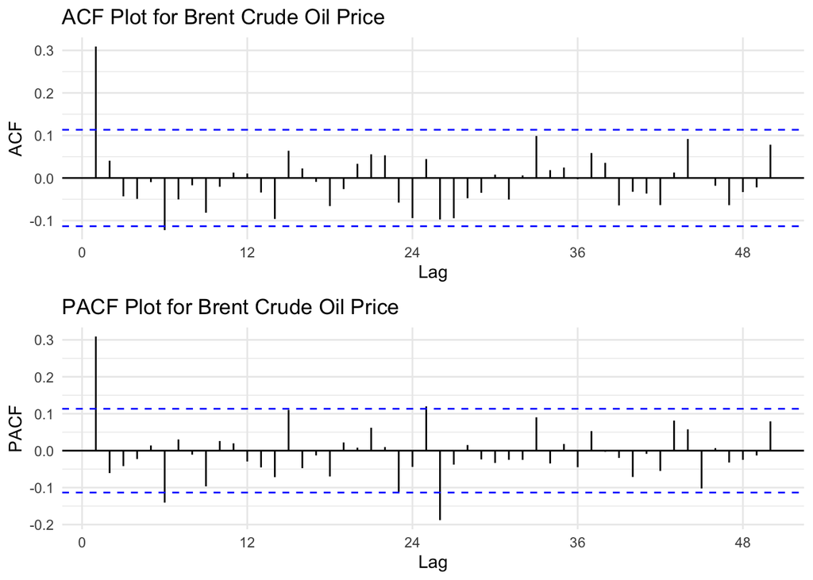

```r
facf4 <- ggAcf(diff(brent_ts), lag.max = 50) +
  ggtitle("ACF Plot for Brent Crude Oil Price") +
  theme_minimal()

fpacf4 <- ggPacf(diff(brent_ts), lag.max = 50) +
  ggtitle("PACF Plot for Brent Crude Oil Price") +
  theme_minimal()

grid.arrange(facf4, fpacf4, nrow = 2)
```

**U.S. Dollar Index**

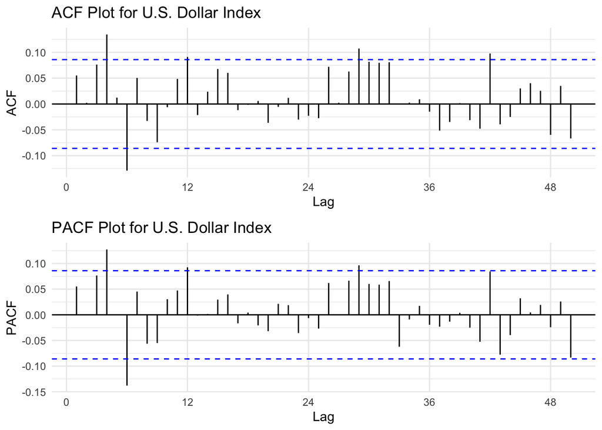

```r
facf5 <- ggAcf(diff(usd_ts), lag.max = 50) +
  ggtitle("ACF Plot for U.S. Dollar Index") +
  theme_minimal()

fpacf5 <- ggPacf(diff(usd_ts), lag.max = 50) +
  ggtitle("PACF Plot for U.S. Dollar Index") +
  theme_minimal()

grid.arrange(facf5, fpacf5, nrow = 2)
```

**Global Supply Chain Pressure Index**

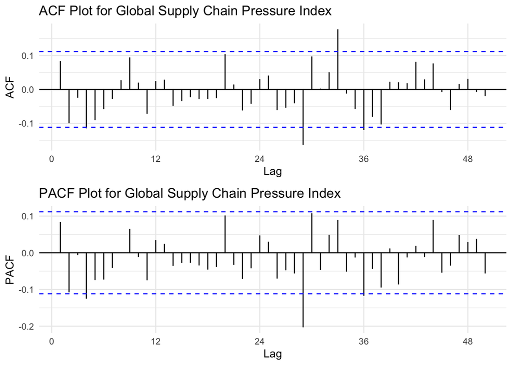

```r
facf6 <- ggAcf(diff(gscpi_ts), lag.max = 50) +
  ggtitle("ACF Plot for Global Supply Chain Pressure Index") +
  theme_minimal()

fpacf6 <- ggPacf(diff(gscpi_ts), lag.max = 50) +
  ggtitle("PACF Plot for Global Supply Chain Pressure Index") +
  theme_minimal()

grid.arrange(facf6, fpacf6, nrow = 2)
```

**AHS Weighted Average Tariff**

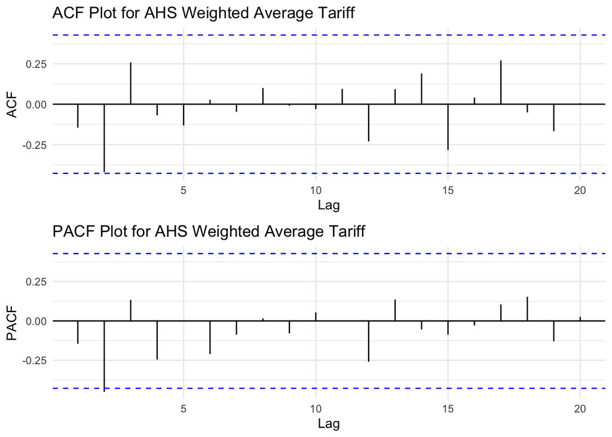

```r
facf7 <- ggAcf(diff(ahs_ts, differences = 2), lag.max = 50) +
  ggtitle("ACF Plot for AHS Weighted Average Tariff") +
  theme_minimal()

fpacf7 <- ggPacf(diff(ahs_ts, differences = 2), lag.max = 50) +
  ggtitle("PACF Plot for AHS Weighted Average Tariff") +
  theme_minimal()

grid.arrange(facf7, fpacf7, nrow = 2)
```

**S&P 500 Index**

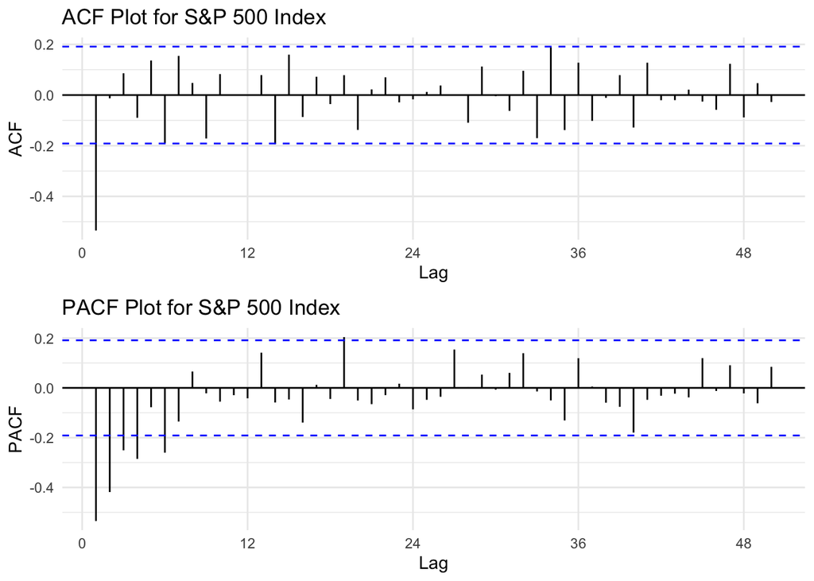

```r
facf8 <- ggAcf(diff(sp500_ts, differences = 2), lag.max = 50) +
  ggtitle("ACF Plot for S&P 500 Index") +
  theme_minimal()

fpacf8 <- ggPacf(diff(sp500_ts, differences = 2), lag.max = 50) +
  ggtitle("PACF Plot for S&P 500 Index") +
  theme_minimal()

grid.arrange(facf8, fpacf8, nrow = 2)
```

**U.S. Retail & Food Services Sales**

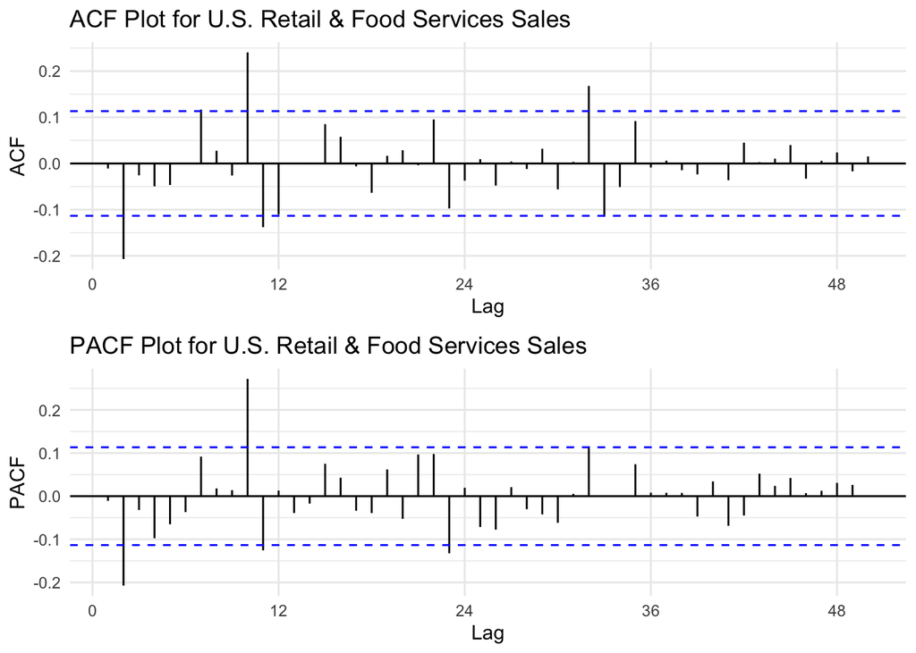

```r
facf9 <- ggAcf(diff(rsafs_ts), lag.max = 50) +
  ggtitle("ACF Plot for U.S. Retail & Food Services Sales") +
  theme_minimal()

fpacf9 <- ggPacf(diff(rsafs_ts), lag.max = 50) +
  ggtitle("PACF Plot for U.S. Retail & Food Services Sales") +
  theme_minimal()

grid.arrange(facf9, fpacf9, nrow = 2)
```

The ACF plot helps determine the q parameter by identifying the number of significant lags in the moving average (MA) component. The PACF plot helps determine the p parameter by identifying the number of significant lags in the autoregressive (AR) component. For seasonal models, ACF and PACF can also be used to determine the seasonal parameters Q and P.

- **Total TEUs (Port of Los Angeles):** Seasonal and ordinary differencing, SARIMA model, d = 1, D = 1, s = 12; p=1,2,4 P=1,2; q=1,4 Q=1.
- **Loaded Imports:** Seasonal and ordinary differencing, SARIMA model, d = 1, D = 1, s = 12; p=1,2,4 P=1,2; q=1,3,4 Q=1.
- **Loaded Exports:** Seasonal and ordinary differencing, SARIMA model, d = 1, D = 1, s = 12; p=1 P=1,2,3; q=1 Q=1.
- **Brent Crude Oil Price:** First-order differencing, ARIMA model, d = 1; p=1,6; q=1,6.
- **U.S. Dollar Index:** First-order differencing, ARIMA model, d = 1; p=4,6; q=4,6.
- **Global Supply Chain Pressure Index (GSCPI):** First-order differencing, ARIMA model, d = 1; p=0; q=4.
- **AHS Weighted Average Tariff:** Second-order differencing, ARIMA model, d = 2; p=2;q=2.
- **S&P 500 Index:** Second-order differencing, ARIMA model, d = 2; p=1,2,3,4,6; q=1.
- **U.S. Retail & Food Services Sales:** First-order differencing, ARIMA model, d = 1; p=2; q=2.

# Model Selection by Manual Search

```r
set.seed(123)

ARIMA.c <- function(p1, p2, q1, q2, data) {
  d <- 1; i <- 1
  ncomb <- (p2 - p1 + 1) * (q2 - q1 + 1)
  ls <- matrix(NA_real_, nrow = ncomb, ncol = 6)

  for (p in p1:p2) for (q in q1:q2) {
    if (p + d + q <= 9) {
      model <- tryCatch(
        forecast::Arima(data, order = c(p, d, q), include.drift = TRUE),
        error = function(e) NULL
      )
      if (!is.null(model)) {
        ls[i, ] <- c(p, d, q, model$aic, model$bic, model$aicc)
        i <- i + 1
      }
    }
  }
  temp <- as.data.frame(ls[seq_len(i - 1), , drop = FALSE])
  names(temp) <- c("p","d","q","AIC","BIC","AICc")
  na.omit(temp)
}

SARIMA.c <- function(p1, p2, q1, q2, P1, P2, Q1, Q2, s, data) {
  d <- 1; D <- 1; i <- 1
  ncomb <- (p2 - p1 + 1) * (q2 - q1 + 1) * (P2 - P1 + 1) * (Q2 - Q1 + 1)
  ls <- matrix(NA_real_, nrow = ncomb, ncol = 9)

  for (p in p1:p2) for (q in q1:q2) for (P in P1:P2) for (Q in Q1:Q2) {
    if (p + d + q + P + D + Q <= 9) {
      model <- tryCatch(
        forecast::Arima(data,
                        order = c(p, d, q),
                        seasonal = list(order = c(P, D, Q), period = s)),
        error = function(e) NULL
      )
      if (!is.null(model)) {
        ls[i, ] <- c(p, d, q, P, D, Q, model$aic, model$bic, model$aicc)
        i <- i + 1
      }
    }
  }
  temp <- as.data.frame(ls[seq_len(i - 1), , drop = FALSE])
  names(temp) <- c("p","d","q","P","D","Q","AIC","BIC","AICc")
  na.omit(temp)
}
```

**Total TEUs**

```r
output1=SARIMA.c(p1=0, p2=4, q1=0, q2=4, P1=0, P2=2, Q1=0, Q2=1, s=12, data=la_teu_ts)
highlight_output(output1, type="SARIMA")
```

Comparison of SARIMA Models

| p | d | q | P | D | Q | AIC | BIC | AICc |
| --- | --- | --- | --- | --- | --- | --- | --- | --- |
| 0 | 1 | 0 | 0 | 1 | 0 | 7407.955 | 7411.615 | 7407.969 |
| 0 | 1 | 0 | 0 | 1 | 1 | 7223.553 | 7230.872 | 7223.595 |
| 0 | 1 | 0 | 1 | 1 | 0 | 7315.150 | 7322.469 | 7315.192 |
| 0 | 1 | 0 | 1 | 1 | 1 | 7223.818 | 7234.796 | 7223.902 |
| 0 | 1 | 0 | 2 | 1 | 0 | 7289.483 | 7300.462 | 7289.568 |
| 0 | 1 | 0 | 2 | 1 | 1 | 7225.797 | 7240.435 | 7225.939 |
| 0 | 1 | 1 | 0 | 1 | 0 | 7333.034 | 7340.353 | 7333.077 |
| 0 | 1 | 1 | 0 | 1 | 1 | 7167.280 | 7178.258 | 7167.364 |
| 0 | 1 | 1 | 1 | 1 | 0 | 7257.166 | 7268.144 | 7257.250 |
| 0 | 1 | 1 | 1 | 1 | 1 | 7169.207 | 7183.845 | 7169.349 |
| 0 | 1 | 1 | 2 | 1 | 0 | 7233.212 | 7247.850 | 7233.354 |
| 0 | 1 | 1 | 2 | 1 | 1 | 7171.101 | 7189.399 | 7171.315 |
| 0 | 1 | 2 | 0 | 1 | 0 | 7334.832 | 7345.811 | 7334.917 |
| 0 | 1 | 2 | 0 | 1 | 1 | 7168.264 | 7182.902 | 7168.405 |
| 0 | 1 | 2 | 1 | 1 | 0 | 7259.095 | 7273.733 | 7259.236 |
| 0 | 1 | 2 | 1 | 1 | 1 | 7170.068 | 7188.365 | 7170.281 |
| 0 | 1 | 2 | 2 | 1 | 0 | 7234.926 | 7253.224 | 7235.140 |
| 0 | 1 | 2 | 2 | 1 | 1 | 7171.906 | 7193.863 | 7172.206 |
| 0 | 1 | 3 | 0 | 1 | 0 | 7336.547 | 7351.185 | 7336.689 |
| 0 | 1 | 3 | 0 | 1 | 1 | 7170.187 | 7188.485 | 7170.401 |
| 0 | 1 | 3 | 1 | 1 | 0 | 7261.086 | 7279.383 | 7261.299 |
| 0 | 1 | 3 | 1 | 1 | 1 | 7171.983 | 7193.940 | 7172.283 |
| 0 | 1 | 3 | 2 | 1 | 0 | 7236.692 | 7258.649 | 7236.992 |
| 0 | 1 | 3 | 2 | 1 | 1 | 7173.809 | 7199.425 | 7174.210 |
| 0 | 1 | 4 | 0 | 1 | 0 | 7337.398 | 7355.695 | 7337.612 |
| 0 | 1 | 4 | 0 | 1 | 1 | 7161.595 | 7183.552 | 7161.895 |
| 0 | 1 | 4 | 1 | 1 | 0 | 7256.148 | 7278.105 | 7256.448 |
| 0 | 1 | 4 | 1 | 1 | 1 | 7162.087 | 7187.704 | 7162.489 |
| 0 | 1 | 4 | 2 | 1 | 0 | 7222.038 | 7247.655 | 7222.440 |
| 0 | 1 | 4 | 2 | 1 | 1 | 7163.617 | 7192.893 | 7164.135 |

[output cut: 88 more lines]

- **Total TEUs (Port of Los Angeles):** ARIMA(0,1,1)(0,1,1)[12]/(3,1,3)(0,1,1)[12]

**Loaded Imports**

```r
output2=SARIMA.c(p1=0, p2=4, q1=0, q2=4, P1=0, P2=2, Q1=0, Q2=1, s=12, data=la_li_ts)
highlight_output(output2, type="SARIMA")
```

Comparison of SARIMA Models

| p | d | q | P | D | Q | AIC | BIC | AICc |
| --- | --- | --- | --- | --- | --- | --- | --- | --- |
| 0 | 1 | 0 | 0 | 1 | 0 | 7116.888 | 7120.547 | 7116.902 |
| 0 | 1 | 0 | 0 | 1 | 1 | 6928.521 | 6935.840 | 6928.563 |
| 0 | 1 | 0 | 1 | 1 | 0 | 7024.504 | 7031.823 | 7024.546 |
| 0 | 1 | 0 | 1 | 1 | 1 | 6928.017 | 6938.996 | 6928.102 |
| 0 | 1 | 0 | 2 | 1 | 0 | 6995.293 | 7006.272 | 6995.378 |
| 0 | 1 | 0 | 2 | 1 | 1 | 6929.845 | 6944.483 | 6929.987 |
| 0 | 1 | 1 | 0 | 1 | 0 | 7017.502 | 7024.821 | 7017.544 |
| 0 | 1 | 1 | 0 | 1 | 1 | 6854.596 | 6865.575 | 6854.681 |
| 0 | 1 | 1 | 1 | 1 | 0 | 6945.898 | 6956.877 | 6945.983 |
| 0 | 1 | 1 | 1 | 1 | 1 | 6856.588 | 6871.226 | 6856.730 |
| 0 | 1 | 1 | 2 | 1 | 0 | 6920.201 | 6934.839 | 6920.343 |
| 0 | 1 | 1 | 2 | 1 | 1 | 6858.327 | 6876.624 | 6858.540 |
| 0 | 1 | 2 | 0 | 1 | 0 | 7018.327 | 7029.305 | 7018.412 |
| 0 | 1 | 2 | 0 | 1 | 1 | 6855.743 | 6870.381 | 6855.885 |
| 0 | 1 | 2 | 1 | 1 | 0 | 6947.866 | 6962.504 | 6948.008 |
| 0 | 1 | 2 | 1 | 1 | 1 | 6857.652 | 6875.950 | 6857.866 |
| 0 | 1 | 2 | 2 | 1 | 0 | 6922.052 | 6940.350 | 6922.266 |
| 0 | 1 | 2 | 2 | 1 | 1 | 6859.273 | 6881.230 | 6859.573 |
| 0 | 1 | 3 | 0 | 1 | 0 | 7019.561 | 7034.199 | 7019.703 |
| 0 | 1 | 3 | 0 | 1 | 1 | 6857.613 | 6875.910 | 6857.826 |
| 0 | 1 | 3 | 1 | 1 | 0 | 6949.866 | 6968.163 | 6950.079 |
| 0 | 1 | 3 | 1 | 1 | 1 | 6859.507 | 6881.464 | 6859.807 |
| 0 | 1 | 3 | 2 | 1 | 0 | 6923.722 | 6945.679 | 6924.022 |
| 0 | 1 | 3 | 2 | 1 | 1 | 6861.116 | 6886.733 | 6861.518 |
| 0 | 1 | 4 | 0 | 1 | 0 | 7020.793 | 7039.091 | 7021.007 |
| 0 | 1 | 4 | 0 | 1 | 1 | 6851.197 | 6873.154 | 6851.497 |
| 0 | 1 | 4 | 1 | 1 | 0 | 6946.539 | 6968.496 | 6946.839 |
| 0 | 1 | 4 | 1 | 1 | 1 | 6852.167 | 6877.783 | 6852.568 |
| 0 | 1 | 4 | 2 | 1 | 0 | 6913.016 | 6938.632 | 6913.417 |
| 0 | 1 | 4 | 2 | 1 | 1 | 6853.567 | 6882.842 | 6854.085 |

[output cut: 91 more lines]

- **Loaded Imports:** SARIMA(0,1,1)(0,1,1)[12]/(3,1,3)(0,1,1)[12]

**Loaded Exports**

```r
output3=SARIMA.c(p1=0, p2=1, q1=0, q2=1, P1=0, P2=3, Q1=0, Q2=1, s=12, data=la_le_ts)
highlight_output(output3, type="SARIMA")
```

Comparison of SARIMA Models

| p | d | q | P | D | Q | AIC | BIC | AICc |
| --- | --- | --- | --- | --- | --- | --- | --- | --- |
| 0 | 1 | 0 | 0 | 1 | 0 | 6329.483 | 6333.143 | 6329.497 |
| 0 | 1 | 0 | 0 | 1 | 1 | 6184.100 | 6191.419 | 6184.142 |
| 0 | 1 | 0 | 1 | 1 | 0 | 6267.996 | 6275.315 | 6268.039 |
| 0 | 1 | 0 | 1 | 1 | 1 | 6185.185 | 6196.164 | 6185.270 |
| 0 | 1 | 0 | 2 | 1 | 0 | 6232.292 | 6243.270 | 6232.376 |
| 0 | 1 | 0 | 2 | 1 | 1 | 6186.835 | 6201.473 | 6186.977 |
| 0 | 1 | 0 | 3 | 1 | 0 | 6226.834 | 6241.472 | 6226.976 |
| 0 | 1 | 0 | 3 | 1 | 1 | 6188.674 | 6206.972 | 6188.888 |
| 0 | 1 | 1 | 0 | 1 | 0 | 6303.236 | 6310.555 | 6303.278 |
| 0 | 1 | 1 | 0 | 1 | 1 | 6148.908 | 6159.886 | 6148.992 |
| 0 | 1 | 1 | 1 | 1 | 0 | 6237.657 | 6248.635 | 6237.741 |
| 0 | 1 | 1 | 1 | 1 | 1 | 6150.611 | 6165.249 | 6150.753 |
| 0 | 1 | 1 | 2 | 1 | 0 | 6197.127 | 6211.765 | 6197.269 |
| 0 | 1 | 1 | 2 | 1 | 1 | 6152.244 | 6170.541 | 6152.458 |
| 0 | 1 | 1 | 3 | 1 | 0 | 6188.693 | 6206.990 | 6188.906 |
| 0 | 1 | 1 | 3 | 1 | 1 | 6153.558 | 6175.515 | 6153.858 |
| 1 | 1 | 0 | 0 | 1 | 0 | 6307.206 | 6314.525 | 6307.249 |
| 1 | 1 | 0 | 0 | 1 | 1 | 6157.282 | 6168.260 | 6157.366 |
| 1 | 1 | 0 | 1 | 1 | 0 | 6243.160 | 6254.139 | 6243.245 |
| 1 | 1 | 0 | 1 | 1 | 1 | 6158.610 | 6173.248 | 6158.752 |
| 1 | 1 | 0 | 2 | 1 | 0 | 6203.967 | 6218.605 | 6204.109 |
| 1 | 1 | 0 | 2 | 1 | 1 | 6160.382 | 6178.679 | 6160.595 |
| 1 | 1 | 0 | 3 | 1 | 0 | 6196.673 | 6214.970 | 6196.886 |
| 1 | 1 | 0 | 3 | 1 | 1 | 6161.663 | 6183.620 | 6161.963 |
| 1 | 1 | 1 | 0 | 1 | 0 | 6296.424 | 6307.402 | 6296.509 |
| 1 | 1 | 1 | 0 | 1 | 1 | 6149.636 | 6164.274 | 6149.778 |
| 1 | 1 | 1 | 1 | 1 | 0 | 6238.263 | 6252.901 | 6238.405 |
| 1 | 1 | 1 | 1 | 1 | 1 | 6151.369 | 6169.667 | 6151.583 |
| 1 | 1 | 1 | 2 | 1 | 0 | 6198.782 | 6217.079 | 6198.995 |
| 1 | 1 | 1 | 2 | 1 | 1 | 6152.945 | 6174.901 | 6153.245 |

- **Loaded Exports:** SARIMA(0,1,1)(0,1,1)[12]

**Brent Crude Oil Price**

```r
output4=ARIMA.c(p1=0,p2=6,q1=0,q2=6,data=brent_ts)
highlight_output(output4)
```

Comparison of ARIMA Models

| p | d | q | AIC | BIC | AICc |
| --- | --- | --- | --- | --- | --- |
| 0 | 1 | 0 | 1930.185 | 1937.586 | 1930.226 |
| 0 | 1 | 1 | 1902.327 | 1913.429 | 1902.409 |
| 0 | 1 | 2 | 1903.201 | 1918.003 | 1903.337 |
| 0 | 1 | 3 | 1905.137 | 1923.639 | 1905.342 |
| 0 | 1 | 4 | 1905.424 | 1927.626 | 1905.711 |
| 0 | 1 | 5 | 1905.832 | 1931.735 | 1906.217 |
| 0 | 1 | 6 | 1904.060 | 1933.664 | 1904.557 |
| 1 | 1 | 0 | 1902.265 | 1913.367 | 1902.347 |
| 1 | 1 | 1 | 1903.401 | 1918.203 | 1903.537 |
| 1 | 1 | 2 | 1905.184 | 1923.686 | 1905.388 |
| 1 | 1 | 3 | 1902.369 | 1924.572 | 1902.657 |
| 1 | 1 | 4 | 1901.212 | 1927.115 | 1901.597 |
| 1 | 1 | 5 | 1906.510 | 1936.114 | 1907.007 |
| 1 | 1 | 6 | 1904.777 | 1938.081 | 1905.400 |
| 2 | 1 | 0 | 1903.169 | 1917.970 | 1903.305 |
| 2 | 1 | 1 | 1900.900 | 1919.402 | 1901.104 |
| 2 | 1 | 2 | 1906.559 | 1928.761 | 1906.846 |
| 2 | 1 | 3 | 1898.905 | 1924.808 | 1899.290 |
| 2 | 1 | 4 | 1899.393 | 1928.997 | 1899.890 |
| 2 | 1 | 5 | 1902.322 | 1935.626 | 1902.945 |
| 2 | 1 | 6 | 1905.603 | 1942.608 | 1906.367 |
| 3 | 1 | 0 | 1904.641 | 1923.143 | 1904.846 |
| 3 | 1 | 1 | 1902.451 | 1924.654 | 1902.739 |
| 3 | 1 | 2 | 1902.089 | 1927.992 | 1902.474 |
| 3 | 1 | 3 | 1900.370 | 1929.973 | 1900.866 |
| 3 | 1 | 4 | 1898.650 | 1931.954 | 1899.272 |
| 3 | 1 | 5 | 1899.791 | 1936.795 | 1900.555 |
| 4 | 1 | 0 | 1906.499 | 1928.702 | 1906.787 |
| 4 | 1 | 1 | 1901.671 | 1927.575 | 1902.056 |
| 4 | 1 | 2 | 1900.365 | 1929.968 | 1900.861 |
| 4 | 1 | 3 | 1903.139 | 1936.443 | 1903.762 |
| 4 | 1 | 4 | 1901.964 | 1938.968 | 1902.727 |
| 5 | 1 | 0 | 1908.440 | 1934.343 | 1908.825 |
| 5 | 1 | 1 | 1903.630 | 1933.233 | 1904.126 |
| 5 | 1 | 2 | 1901.515 | 1934.819 | 1902.138 |
| 5 | 1 | 3 | 1899.798 | 1936.803 | 1900.562 |
| 6 | 1 | 0 | 1904.482 | 1934.085 | 1904.978 |
| 6 | 1 | 1 | 1906.236 | 1939.540 | 1906.859 |
| 6 | 1 | 2 | 1905.354 | 1942.358 | 1906.118 |

- **Brent Crude Oil Price:** ARIMA(1,1,0)/(3,1,4)

**U.S. Dollar Index**

```r
output5=ARIMA.c(p1=4,p2=6,q1=4,q2=6,data=usd_ts)
highlight_output(output5)
```

Comparison of ARIMA Models

| p | d | q | AIC | BIC | AICc |
| --- | --- | --- | --- | --- | --- |
| 4 | 1 | 4 | 3820.709 | 3885.394 | 3820.756 |

- **U.S. Dollar Index:** ARIMA(4,1,4)

**Global Supply Chain Pressure Index (GSCPI)**

```r
output6=ARIMA.c(p1=0,p2=1,q1=0,q2=4,data=gscpi_ts)
highlight_output(output6)
```

Comparison of ARIMA Models

| p | d | q | AIC | BIC | AICc |
| --- | --- | --- | --- | --- | --- |
| 0 | 1 | 0 | 288.5265 | 295.9867 | 288.5658 |
| 0 | 1 | 1 | 287.8041 | 298.9944 | 287.8831 |
| 0 | 1 | 2 | 285.9957 | 300.9161 | 286.1278 |
| 0 | 1 | 3 | 287.7271 | 306.3776 | 287.9258 |
| 0 | 1 | 4 | 285.4729 | 307.8535 | 285.7519 |
| 1 | 1 | 0 | 288.3643 | 299.5546 | 288.4433 |
| 1 | 1 | 1 | 286.8354 | 301.7558 | 286.9674 |
| 1 | 1 | 2 | 278.3040 | 296.9545 | 278.5027 |
| 1 | 1 | 3 | 279.2841 | 301.6647 | 279.5632 |
| 1 | 1 | 4 | 285.1701 | 311.2808 | 285.5434 |

- **Global Supply Chain Pressure Index (GSCPI):** ARIMA(0,1,0)/(1,1,2)

```r
ARIMA2.c <- function(p1, p2, q1, q2, data) {
  d <- 2; i <- 1
  ncomb <- (p2 - p1 + 1) * (q2 - q1 + 1)
  ls <- matrix(NA_real_, nrow = ncomb, ncol = 6)

  for (p in p1:p2) for (q in q1:q2) {
    if (p + d + q <= 9) {
      model <- tryCatch(
        forecast::Arima(data, order = c(p, d, q), include.drift = TRUE),
        error = function(e) NULL
      )
      if (!is.null(model)) {
        ls[i, ] <- c(p, d, q, model$aic, model$bic, model$aicc)
        i <- i + 1
      }
    }
  }

  temp <- as.data.frame(ls[seq_len(i-1), , drop = FALSE])
  names(temp) <- c("p","d","q","AIC","BIC","AICc")
  na.omit(temp)
}
```

```r
output7<- ARIMA2.c(p1=0, p2=2, q1=0, q2=2, data=gscpi_ts)
highlight_output(output7, type="ARIMA (d=2)")
```

Comparison of ARIMA (d=2) Models

| p | d | q | AIC | BIC | AICc |
| --- | --- | --- | --- | --- | --- |
| 0 | 2 | 0 | 472.4023 | 476.1291 | 472.4154 |
| 0 | 2 | 1 | 294.3312 | 301.7849 | 294.3706 |
| 0 | 2 | 2 | 293.4153 | 304.5958 | 293.4945 |
| 1 | 2 | 0 | 421.0943 | 428.5480 | 421.1338 |
| 1 | 2 | 1 | 293.9984 | 305.1789 | 294.0776 |
| 1 | 2 | 2 | 292.5196 | 307.4270 | 292.6521 |
| 2 | 2 | 0 | 380.9384 | 392.1189 | 381.0176 |
| 2 | 2 | 1 | 292.6449 | 307.5523 | 292.7774 |
| 2 | 2 | 2 | 294.2105 | 312.8448 | 294.4099 |

**S&P 500 Index**

```r
output8<- ARIMA2.c(p1=0, p2=6, q1=0, q2=1, data=sp500_ts)
highlight_output(output8, type="ARIMA (d=2)")
```

Comparison of ARIMA (d=2) Models

| p | d | q | AIC | BIC | AICc |
| --- | --- | --- | --- | --- | --- |
| 0 | 2 | 0 | 1452.342 | 1454.996 | 1452.381 |
| 0 | 2 | 1 | 1373.863 | 1379.171 | 1373.980 |
| 1 | 2 | 0 | 1418.294 | 1423.602 | 1418.412 |
| 1 | 2 | 1 | 1373.807 | 1381.769 | 1374.044 |
| 2 | 2 | 0 | 1399.221 | 1407.183 | 1399.459 |
| 2 | 2 | 1 | 1375.367 | 1385.983 | 1375.767 |
| 3 | 2 | 0 | 1393.725 | 1404.340 | 1394.125 |
| 3 | 2 | 1 | 1377.028 | 1390.298 | 1377.634 |
| 4 | 2 | 0 | 1385.576 | 1398.846 | 1386.183 |
| 4 | 2 | 1 | 1379.395 | 1395.319 | 1380.252 |
| 5 | 2 | 0 | 1386.594 | 1402.517 | 1387.451 |
| 5 | 2 | 1 | 1378.968 | 1397.546 | 1380.122 |
| 6 | 2 | 0 | 1380.682 | 1399.259 | 1381.836 |
| 6 | 2 | 1 | 1380.320 | 1401.552 | 1381.820 |

- **S&P 500 Index:** ARIMA model(0,2,1)/(1,2,1)

**U.S. Retail & Food Services Sales**

```r
output9=ARIMA.c(p1=0,p2=2,q1=0,q2=2,data=rsafs_ts)
highlight_output(output9)
```

Comparison of ARIMA Models

| p | d | q | AIC | BIC | AICc |
| --- | --- | --- | --- | --- | --- |
| 0 | 1 | 0 | 6288.509 | 6295.910 | 6288.549 |
| 0 | 1 | 1 | 6290.449 | 6301.550 | 6290.530 |
| 0 | 1 | 2 | 6276.955 | 6291.757 | 6277.091 |
| 1 | 1 | 0 | 6290.474 | 6301.575 | 6290.555 |
| 1 | 1 | 1 | 6286.026 | 6300.828 | 6286.163 |
| 1 | 1 | 2 | 6278.599 | 6297.101 | 6278.803 |
| 2 | 1 | 0 | 6279.421 | 6294.223 | 6279.558 |
| 2 | 1 | 1 | 6279.746 | 6298.249 | 6279.951 |
| 2 | 1 | 2 | 6280.538 | 6302.740 | 6280.825 |

- **U.S. Retail & Food Services Sales:** ARIMA(0,1,2)

# Model Selection by Auto.arima()

**Total TEUs**

```r
auto.arima(la_teu_ts)
```

```
Series: la_teu_ts
ARIMA(0,1,1)(0,0,2)[12]

Coefficients:
          ma1    sma1    sma2
      -0.4286  0.1809  0.1949
s.e.   0.0586  0.0599  0.0603

sigma^2 = 4.544e+09:  log likelihood = -3747.91
AIC=7503.81   AICc=7503.95   BIC=7518.61
```

Auto Model chooses sarima(0,1,1)(0,0,2)[12] for Total TEUs.

**Loaded Imports**

```r
auto.arima(la_li_ts)
```

```
Series: la_li_ts
ARIMA(0,1,1)(0,0,2)[12]

Coefficients:
          ma1    sma1    sma2
      -0.4865  0.1953  0.1964
s.e.   0.0603  0.0611  0.0605

sigma^2 = 1.559e+09:  log likelihood = -3588.04
AIC=7184.08   AICc=7184.21   BIC=7198.88
```

Auto Model chooses sarima(0,1,1)(0,0,2)[12] for Loaded Imports.

**Loaded Exports**

```r
auto.arima(la_le_ts)
```

```
Series: la_le_ts
ARIMA(1,1,2)(0,0,2)[12]

Coefficients:
         ar1      ma1     ma2    sma1    sma2
      0.8261  -1.2556  0.3093  0.2173  0.1244
s.e.  0.1259   0.1444  0.1005  0.0620  0.0559

sigma^2 = 125056653:  log likelihood = -3209.59
AIC=6431.19   AICc=6431.47   BIC=6453.39
```

Auto Model chooses sarima(1,1,2)(0,0,2)[12] for Loaded Exports.

**Brent Crude Oil Price**

```r
auto.arima(brent_ts)
```

```
Series: brent_ts
ARIMA(0,1,1)

Coefficients:
         ma1
      0.3075
s.e.  0.0525

sigma^2 = 33.38:  log likelihood = -948.23
AIC=1900.47   AICc=1900.51   BIC=1907.87
```

Auto Model chooses arima(0,1,1) for Brent Crude Oil Price.

**U.S. Dollar Index**

```r
auto.arima(usd_ts)
```

```
Series: usd_ts
ARIMA(4,1,2)(0,0,1)[12] with drift

Coefficients:
         ar1      ar2     ar3     ar4      ma1     ma2    sma1   drift
      0.3243  -0.8522  0.0577  0.0152  -0.2950  0.8492  0.0298  0.0058
s.e.  0.1153   0.0483  0.0172  0.0211   0.1144  0.0458  0.0156  0.0056

sigma^2 = 0.1265:  log likelihood = -1898.47
AIC=3814.94   AICc=3814.98   BIC=3873.52
```

Auto Model chooses sarima(4,1,2)(0,0,1)[12] for U.S. Dollar Index.

**Global Supply Chain Pressure Index**

```r
auto.arima(gscpi_ts)
```

```
Series: gscpi_ts
ARIMA(0,1,0)

sigma^2 = 0.1475:  log likelihood = -142.27
AIC=286.54   AICc=286.55   BIC=290.27
```

Auto Model chooses arima(0,1,0) for Global Supply Chain Pressure Index.

**AHS Weighted Average Tariff**

```r
auto.arima(ahs_ts)
```

```
Series: ahs_ts
ARIMA(0,1,0) with drift

Coefficients:
        drift
      -0.1643
s.e.   0.0758

sigma^2 = 0.1325:  log likelihood = -8.47
AIC=20.94   AICc=21.57   BIC=23.12
```

Auto Model chooses arima(0,1,0) for AHS Weighted Average Tariff.

**S&P 500 Index**

```r
auto.arima(sp500_ts)
```

```
Series: sp500_ts
ARIMA(0,1,1) with drift

Coefficients:
          ma1    drift
      -0.1527  36.9643
s.e.   0.0970  13.0739

sigma^2 = 25633:  log likelihood = -687.45
AIC=1380.89   AICc=1381.13   BIC=1388.88
```

Auto Model chooses arima(0,1,1) for S&P 500 Index.

**U.S. Retail & Food Services Sales**

```r
auto.arima(rsafs_ts)
```

```
Series: rsafs_ts
ARIMA(2,1,0) with drift

Coefficients:
          ar1      ar2     drift
      -0.0132  -0.2061  1518.789
s.e.   0.0565   0.0564   411.962

sigma^2 = 76025016:  log likelihood = -3135.71
AIC=6279.42   AICc=6279.56   BIC=6294.22
```

Auto Model chooses arima(2,1,0) for U.S. Retail & Food Services Sales.

# Model Diagnostics

**Total TEUs**

### SARIMA(0,1,1)(0,1,1)[12]

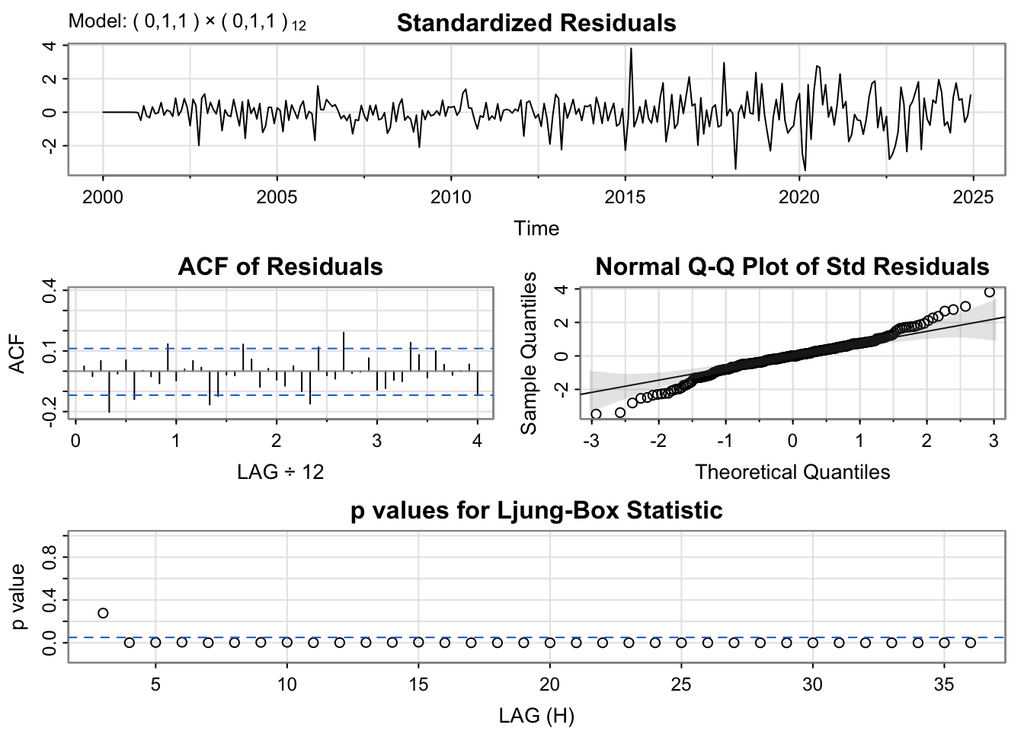

```r
library(astsa)
model_output1_1 <- capture.output(sarima(la_teu_ts, 0,1,1,0,1,1,12))
```

```r
start_line <- grep("Coefficients", model_output1_1)
end_line <- length(model_output1_1)
cat(model_output1_1[start_line:end_line], sep = "\n")
```

```
Coefficients:
     Estimate     SE  t.value p.value
ma1   -0.5021 0.0576  -8.7217       0
sma1  -1.0000 0.0774 -12.9176       0

sigma^2 estimated as 3509917647 on 285 degrees of freedom

AIC = 24.9731  AICc = 24.97325  BIC = 25.01135
```

### SARIMA(3,1,3)(0,1,1)[12]

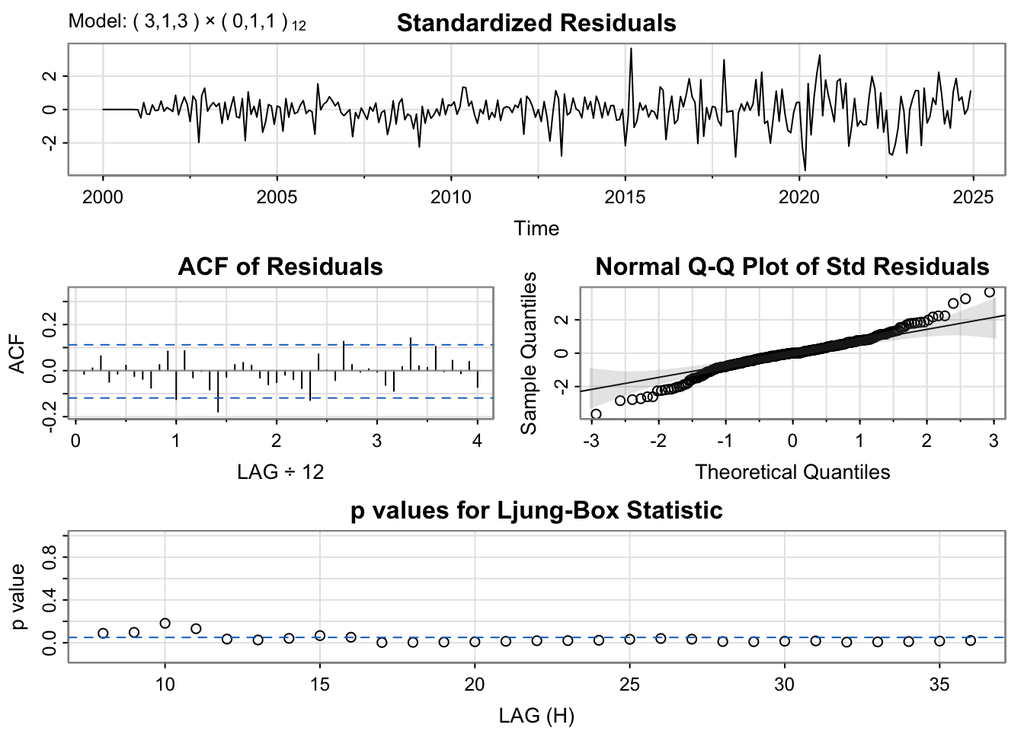

```r
model_output1_2 <- capture.output(sarima(la_teu_ts, 3,1,3,0,1,1,12))
```

```r
start_line <- grep("Coefficients", model_output1_2)
end_line <- length(model_output1_2)
cat(model_output1_2[start_line:end_line], sep = "\n")
```

```
Coefficients:
     Estimate     SE t.value p.value
ar1   -0.6651 0.1402 -4.7451  0.0000
ar2   -0.5258 0.1579 -3.3291  0.0010
ar3    0.3945 0.1344  2.9363  0.0036
ma1    0.2332 0.1146  2.0353  0.0428
ma2    0.1802 0.1111  1.6223  0.1059
ma3   -0.7261 0.0970 -7.4876  0.0000
sma1  -0.9996 0.1090 -9.1665  0.0000

sigma^2 estimated as 3198499301 on 280 degrees of freedom

AIC = 24.927  AICc = 24.9284  BIC = 25.02901
```

### SARIMA(0,1,1)(0,0,2)[12]

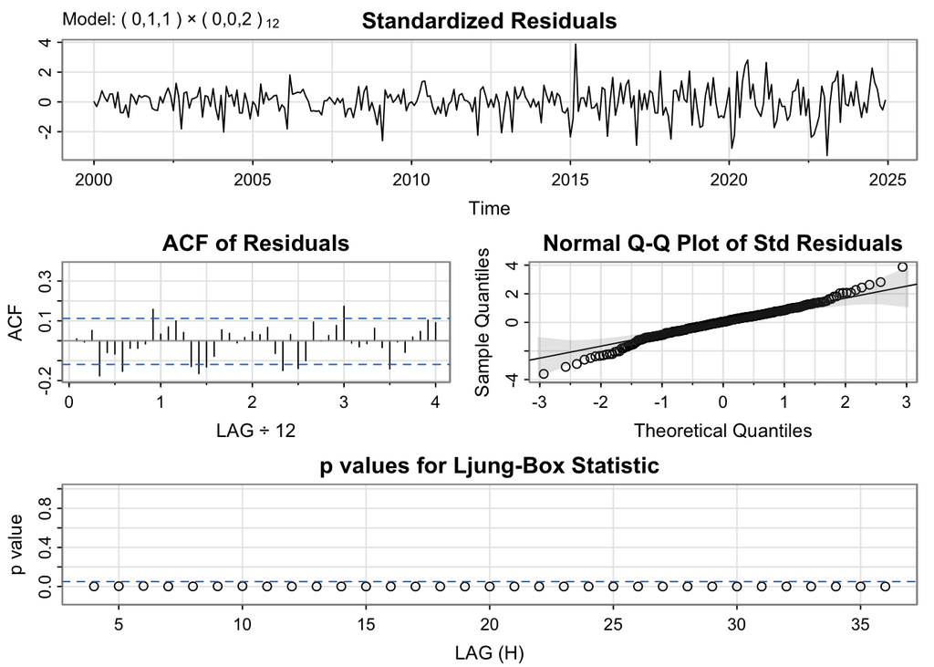

```r
model_output1_3 <- capture.output(sarima(la_teu_ts, 0,1,1,0,0,2,12))
```

```r
start_line <- grep("Coefficients", model_output1_3)
end_line <- length(model_output1_3)
cat(model_output1_3[start_line:end_line], sep = "\n")
```

```
Coefficients:
          Estimate        SE t.value p.value
ma1        -0.4313    0.0589 -7.3253  0.0000
sma1        0.1807    0.0598  3.0210  0.0027
sma2        0.1944    0.0602  3.2262  0.0014
constant 2083.5573 2989.6073  0.6969  0.4864

sigma^2 estimated as 4491296622 on 295 degrees of freedom

AIC = 25.10144  AICc = 25.10189  BIC = 25.16332
```

**Loaded Imports**

### SARIMA(0,1,1)(0,1,1)[12]

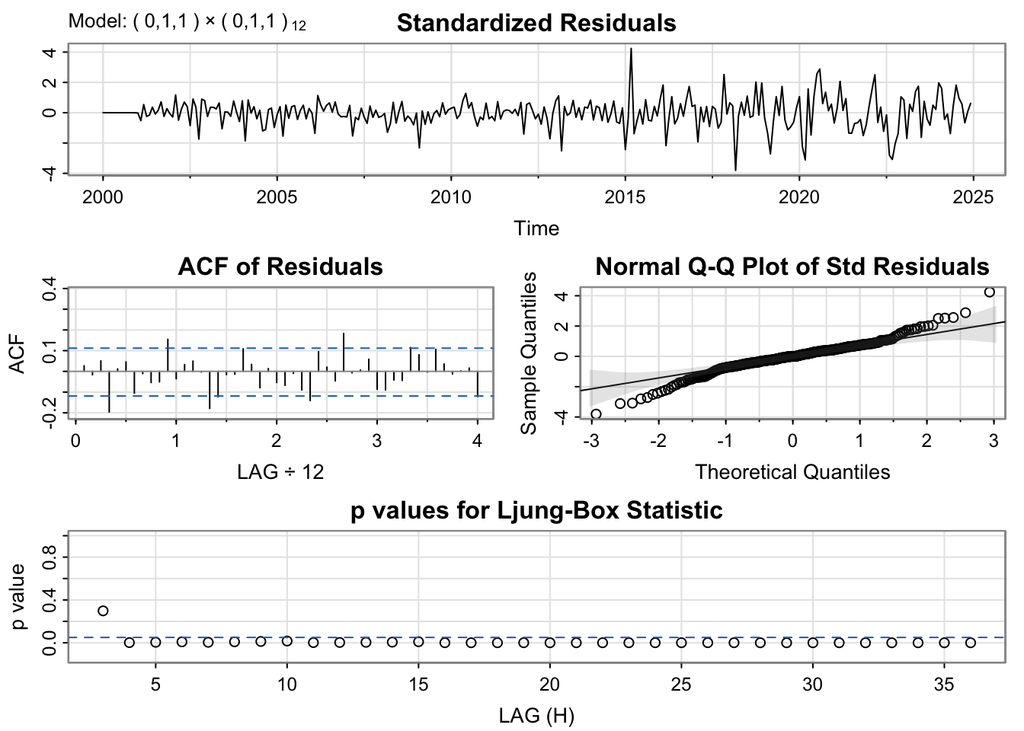

```r
model_output2_1 <- capture.output(sarima(la_li_ts, 0,1,1,0,1,1,12))
```

```r
start_line <- grep("Coefficients", model_output2_1)
end_line <- length(model_output2_1)
cat(model_output2_1[start_line:end_line], sep = "\n")
```

```
Coefficients:
     Estimate     SE  t.value p.value
ma1   -0.5806 0.0544 -10.6714       0
sma1  -1.0000 0.0847 -11.8004       0

sigma^2 estimated as 1180190807 on 285 degrees of freedom

AIC = 23.88361  AICc = 23.88376  BIC = 23.92186
```

### SARIMA(3,1,3)(0,1,1)[12]

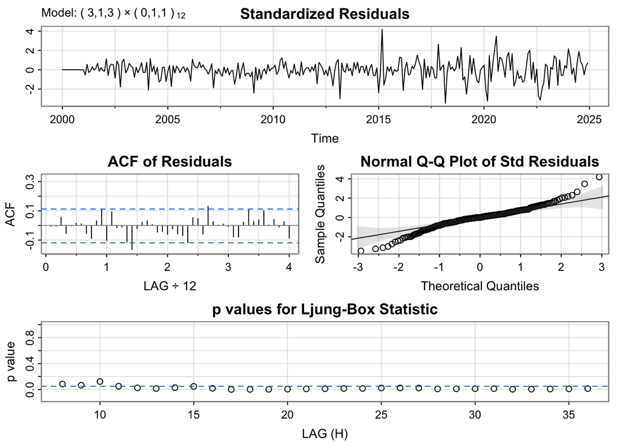

```r
model_output2_2 <- capture.output(sarima(la_li_ts, 3,1,3,0,1,1,12))
```

```r
start_line <- grep("Coefficients", model_output2_2)
end_line <- length(model_output2_2)
cat(model_output2_2[start_line:end_line], sep = "\n")
```

```
Coefficients:
     Estimate     SE t.value p.value
ar1   -0.7527 0.1220 -6.1676  0.0000
ar2   -0.6121 0.1368 -4.4732  0.0000
ar3    0.2988 0.1114  2.6824  0.0077
ma1    0.2338 0.1009  2.3179  0.0212
ma2    0.1859 0.0915  2.0317  0.0431
ma3   -0.6943 0.0785 -8.8414  0.0000
sma1  -0.9998 0.1309 -7.6405  0.0000

sigma^2 estimated as 1094707689 on 280 degrees of freedom

AIC = 23.85172  AICc = 23.85312  BIC = 23.95373
```

Considering all model diagnostics and information criteria, SARIMA(3,1,3)(0,1,1)[12] was selected as the best-fitting model.

**Loaded Exports**

### SARIMA(0,1,1)(0,1,1)[12]

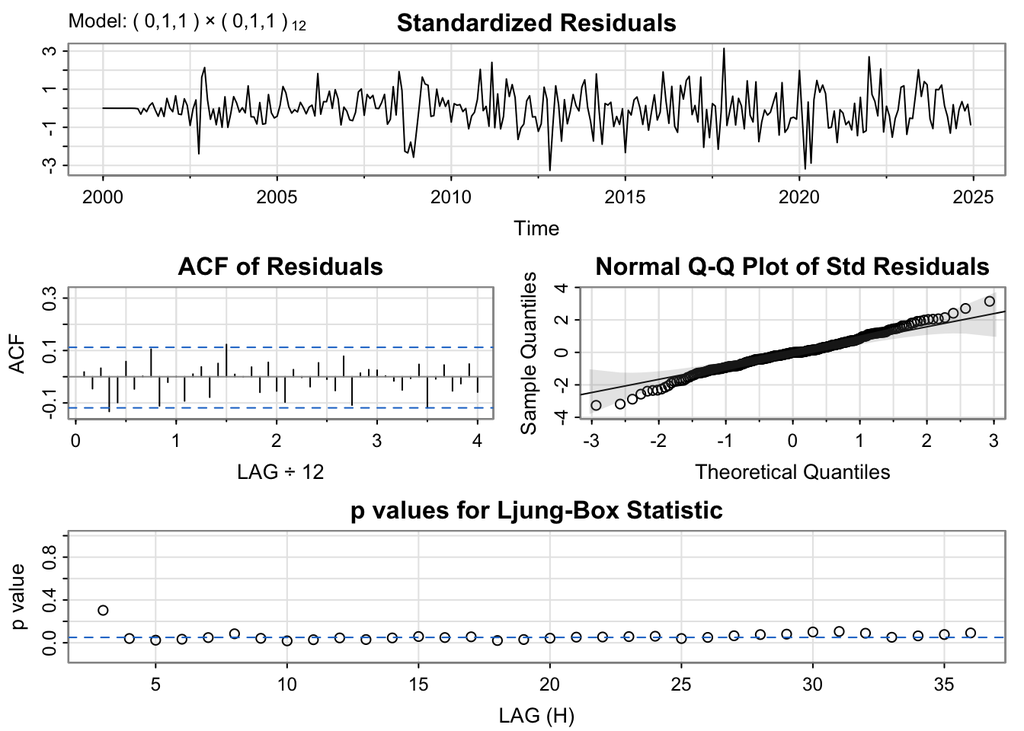

```r
model_output3_1 <- capture.output(sarima(la_le_ts, 0,1,1,0,1,1,12))
```

```r
start_line <- grep("Coefficients", model_output3_1)
end_line <- length(model_output3_1)
cat(model_output3_1[start_line:end_line], sep = "\n")
```

```
Coefficients:
     Estimate     SE  t.value p.value
ma1   -0.3952 0.0593  -6.6599       0
sma1  -0.9571 0.0820 -11.6767       0

sigma^2 estimated as 104718080 on 285 degrees of freedom

AIC = 21.42477  AICc = 21.42491  BIC = 21.46302
```

### SARIMA(1,1,2)(0,0,2)[12]

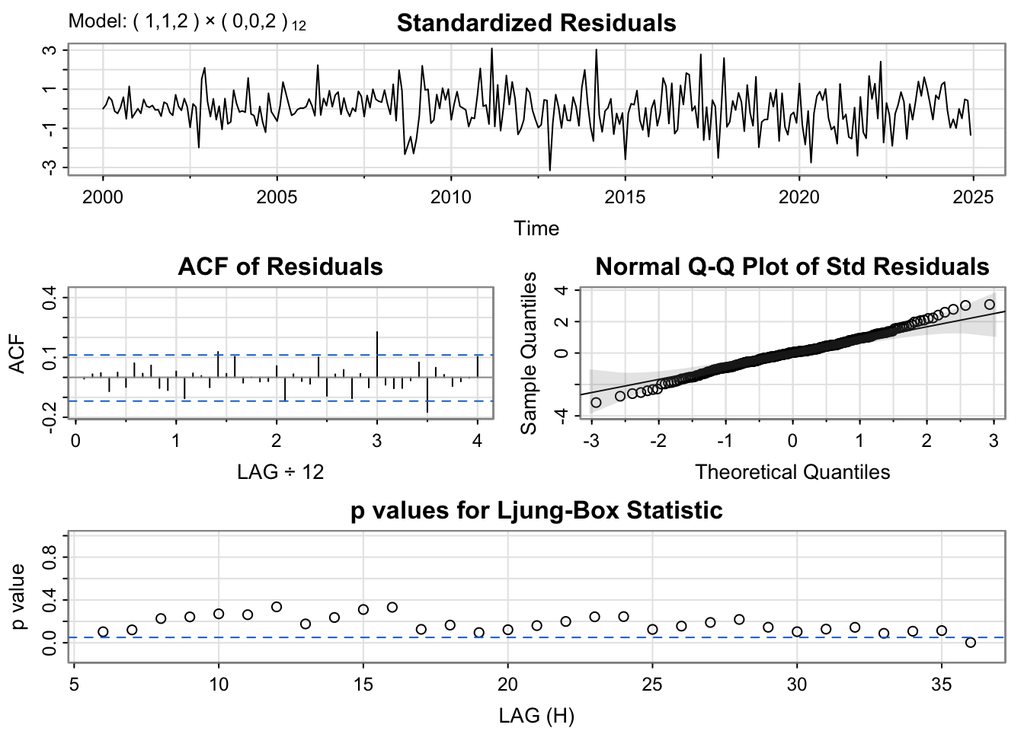

```r
model_output3_2 <- capture.output(sarima(la_le_ts, 1,1,2,0,0,2,12))
```

```r
start_line <- grep("Coefficients", model_output3_2)
end_line <- length(model_output3_2)
cat(model_output3_2[start_line:end_line], sep = "\n")
```

```
Coefficients:
         Estimate       SE t.value p.value
ar1        0.8323   0.1183  7.0333  0.0000
ma1       -1.2631   0.1376 -9.1773  0.0000
ma2        0.3133   0.0979  3.1991  0.0015
sma1       0.2173   0.0620  3.5079  0.0005
sma2       0.1244   0.0559  2.2227  0.0270
constant 131.3228 261.2086  0.5028  0.6155

sigma^2 estimated as 122861191 on 293 degrees of freedom

AIC = 21.51484  AICc = 21.5158  BIC = 21.60147
```

Considering all model diagnostics and information criteria, SARIMA(1,1,2)(0,0,2)[12] was selected as the best-fitting model.

**Brent Crude Oil Price**

### ARIMA(1,1,0)

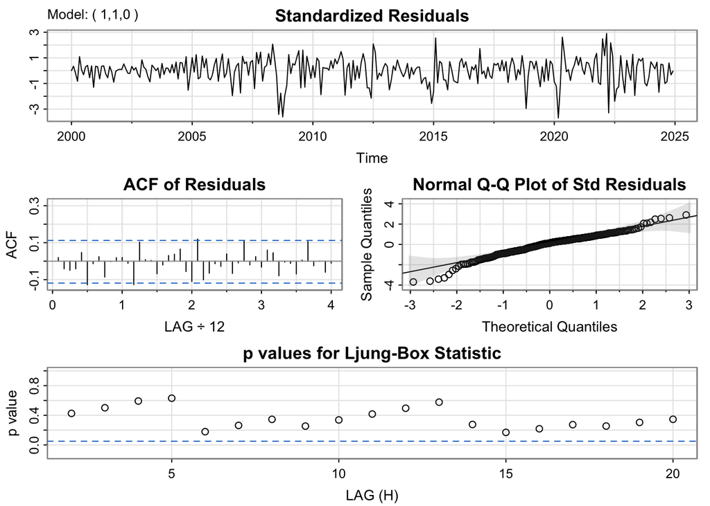

```r
model_output4_1 <- capture.output(sarima(brent_ts,1,1,0))
```

```r
start_line <- grep("Coefficients", model_output4_1)
end_line <- length(model_output4_1)
cat(model_output4_1[start_line:end_line], sep = "\n")
```

```
Coefficients:
         Estimate     SE t.value p.value
ar1        0.3081 0.0549  5.6139  0.0000
constant   0.1640 0.4812  0.3407  0.7335

sigma^2 estimated as 33.24198 on 297 degrees of freedom

AIC = 6.362091  AICc = 6.362227  BIC = 6.399219
```

### ARIMA(3,1,4)

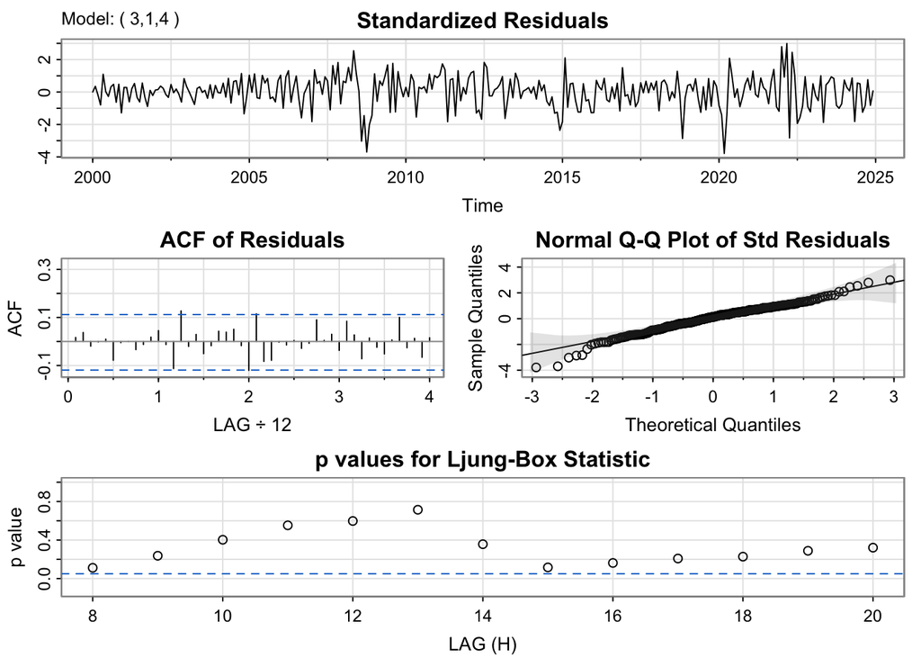

```r
model_output4_2 <- capture.output(sarima(brent_ts,3,1,4))
```

```r
start_line <- grep("Coefficients", model_output4_2)
end_line <- length(model_output4_2)
cat(model_output4_2[start_line:end_line], sep = "\n")
```

```
Coefficients:
         Estimate     SE  t.value p.value
ar1       -0.3104 0.0370  -8.3827   0.000
ar2        0.2686 0.0303   8.8667   0.000
ar3        0.9144 0.0391  23.3951   0.000
ma1        0.6218 0.0610  10.1963   0.000
ma2       -0.1699 0.0246  -6.9184   0.000
ma3       -1.0799 0.0316 -34.2073   0.000
ma4       -0.3720 0.0554  -6.7097   0.000
constant   0.1514 0.1036   1.4612   0.145

sigma^2 estimated as 31.17937 on 291 degrees of freedom

AIC = 6.349999  AICc = 6.35166  BIC = 6.461383
```

### ARIMA(0,1,1)

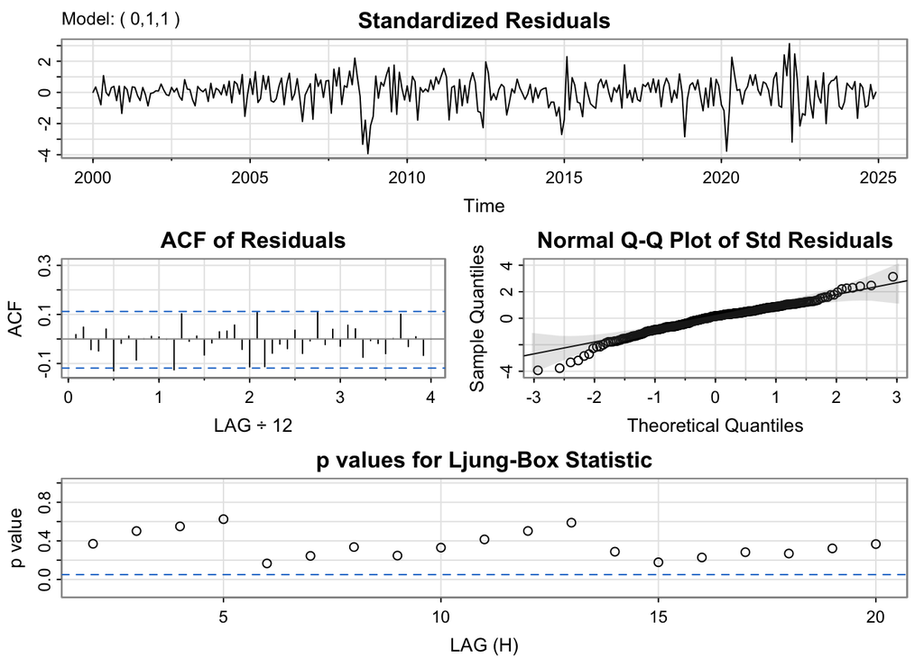

```r
model_output4_3 <- capture.output(sarima(brent_ts,0,1,1))
```

```r
start_line <- grep("Coefficients", model_output4_3)
end_line <- length(model_output4_3)
cat(model_output4_3[start_line:end_line], sep = "\n")
```

```
Coefficients:
         Estimate     SE t.value p.value
ma1        0.3072 0.0526  5.8440  0.0000
constant   0.1635 0.4356  0.3754  0.7076

sigma^2 estimated as 33.24897 on 297 degrees of freedom

AIC = 6.362299  AICc = 6.362435  BIC = 6.399427
```

Considering all model diagnostics and information criteria, ARIMA(1,1,0) was selected as the best-fitting model.

**U.S. Dollar Index**

### ARIMA(4,1,4)

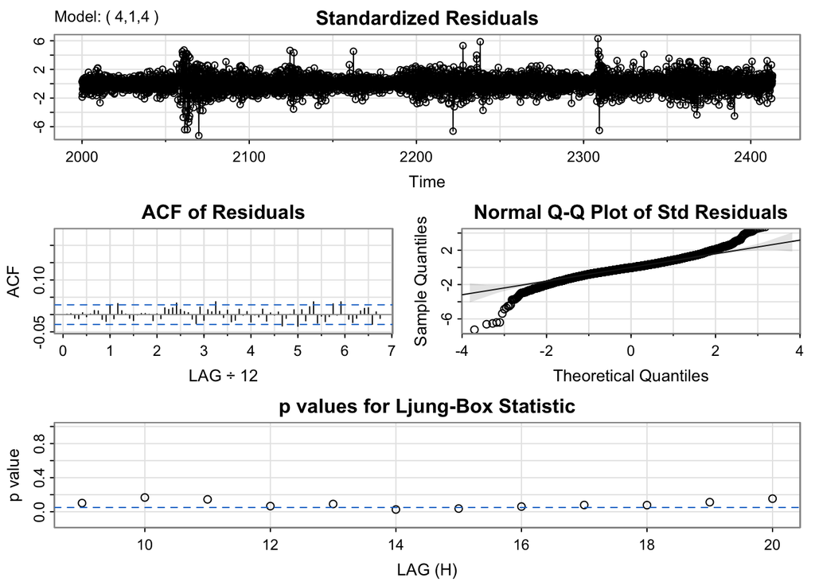

```r
model_output5_1 <- capture.output(sarima(usd_ts,4,1,4))
```

```r
start_line <- grep("Coefficients", model_output5_1)
end_line <- length(model_output5_1)
cat(model_output5_1[start_line:end_line], sep = "\n")
```

```
Coefficients:
         Estimate     SE t.value p.value
ar1       -0.2664    NaN     NaN     NaN
ar2       -0.5942    NaN     NaN     NaN
ar3       -0.4842    NaN     NaN     NaN
ar4        0.1018 0.1214  0.8382  0.4020
ma1        0.2951    NaN     NaN     NaN
ma2        0.6075    NaN     NaN     NaN
ma3        0.5390    NaN     NaN     NaN
ma4       -0.0503 0.1401 -0.3589  0.7197
constant   0.0057 0.0054  1.0676  0.2858

sigma^2 estimated as 0.1263711 on 4753 degrees of freedom

AIC = 0.8023329  AICc = 0.8023409  BIC = 0.8159163
```

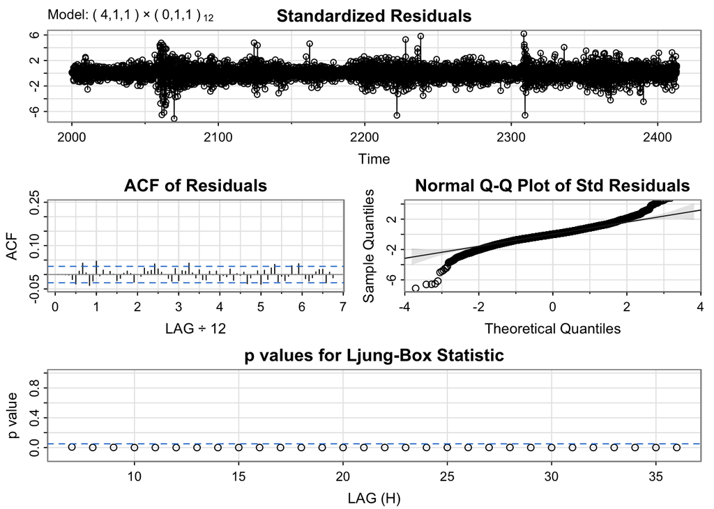

```r
model_output5_2 <- capture.output(sarima(usd_ts, 4,1,1,0,1,1,12))
```

```r
start_line <- grep("Coefficients", model_output5_2)
end_line <- length(model_output5_2)
cat(model_output5_2[start_line:end_line], sep = "\n")
```

```
Coefficients:
     Estimate     SE  t.value p.value
ar1   -0.2662 0.4121  -0.6461  0.5183
ar2    0.0102 0.0195   0.5228  0.6011
ar3    0.0253 0.0152   1.6597  0.0971
ar4    0.0229 0.0170   1.3473  0.1780
ma1    0.2956 0.4118   0.7178  0.4729
sma1  -1.0000 0.0136 -73.6583  0.0000

sigma^2 estimated as 0.1272345 on 4744 degrees of freedom

AIC = 0.8229025  AICc = 0.8229062  BIC = 0.8324312
```

Considering all model diagnostics and information criteria, ARIMA(4,1,4) was selected as the best-fitting model.

**Global Supply Chain Pressure Index**

### ARIMA(0,1,0)

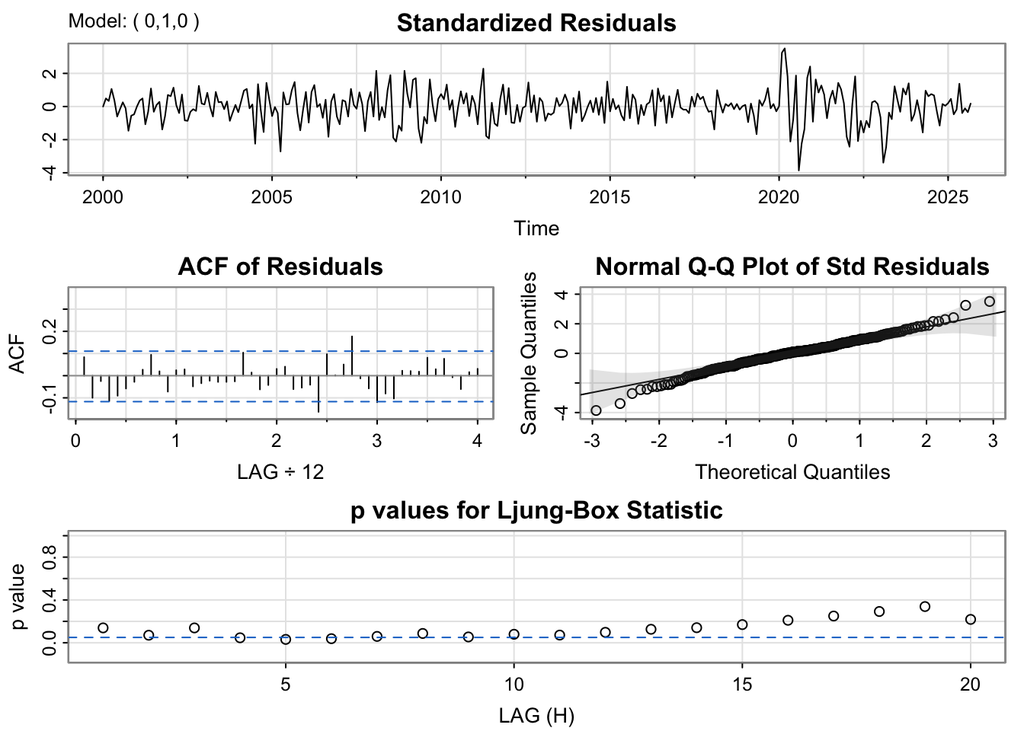

```r
model_output6_1 <- capture.output(sarima(gscpi_ts,0,1,0))
```

```r
start_line <- grep("Coefficients", model_output6_1)
end_line <- length(model_output6_1)
cat(model_output6_1[start_line:end_line], sep = "\n")
```

```
Coefficients:
         Estimate     SE t.value p.value
constant    0.002 0.0219  0.0935  0.9256

sigma^2 estimated as 0.147476 on 307 degrees of freedom

AIC = 0.9367743  AICc = 0.9368168  BIC = 0.9609958
```

### ARIMA(1,1,2)

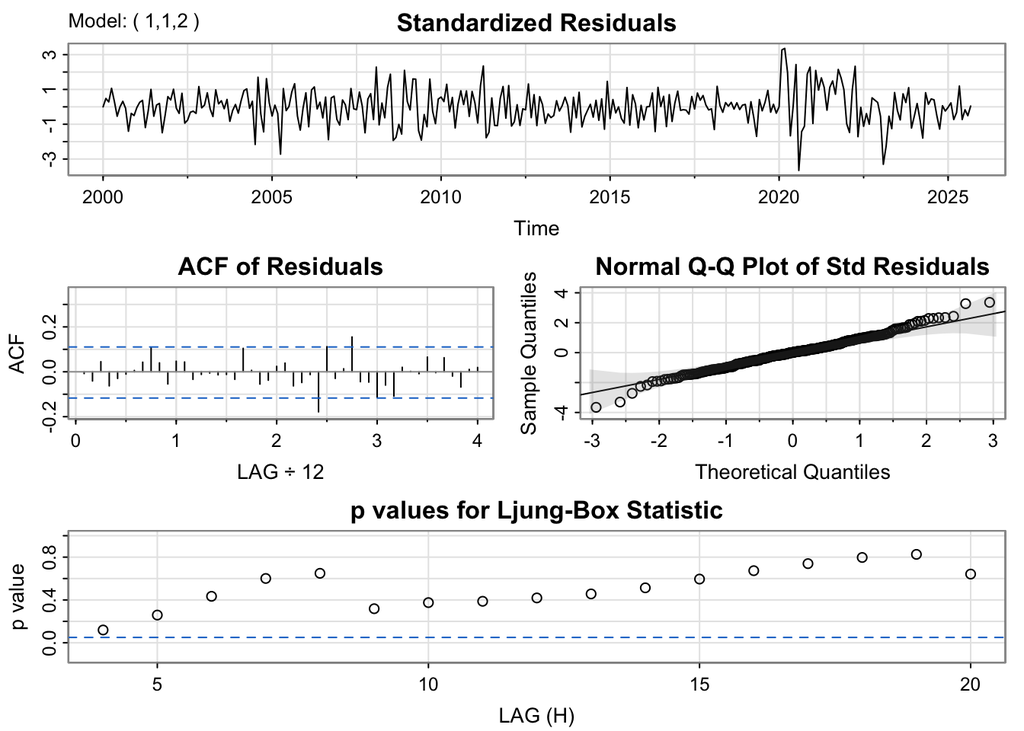

```r
model_output6_2 <- capture.output(sarima(gscpi_ts,1,1,2))
```

```r
start_line <- grep("Coefficients", model_output6_2)
end_line <- length(model_output6_2)
cat(model_output6_2[start_line:end_line], sep = "\n")
```

```
Coefficients:
         Estimate     SE  t.value p.value
ar1        0.8939 0.0290  30.8655  0.0000
ma1       -0.8395 0.0662 -12.6761  0.0000
ma2       -0.1605 0.0656  -2.4466  0.0150
constant   0.0044 0.0024   1.8537  0.0647

sigma^2 estimated as 0.1385977 on 304 degrees of freedom

AIC = 0.9035844  AICc = 0.904013  BIC = 0.964138
```

**AHS Weighted Average Tariff**

### ARIMA(0,2,1)

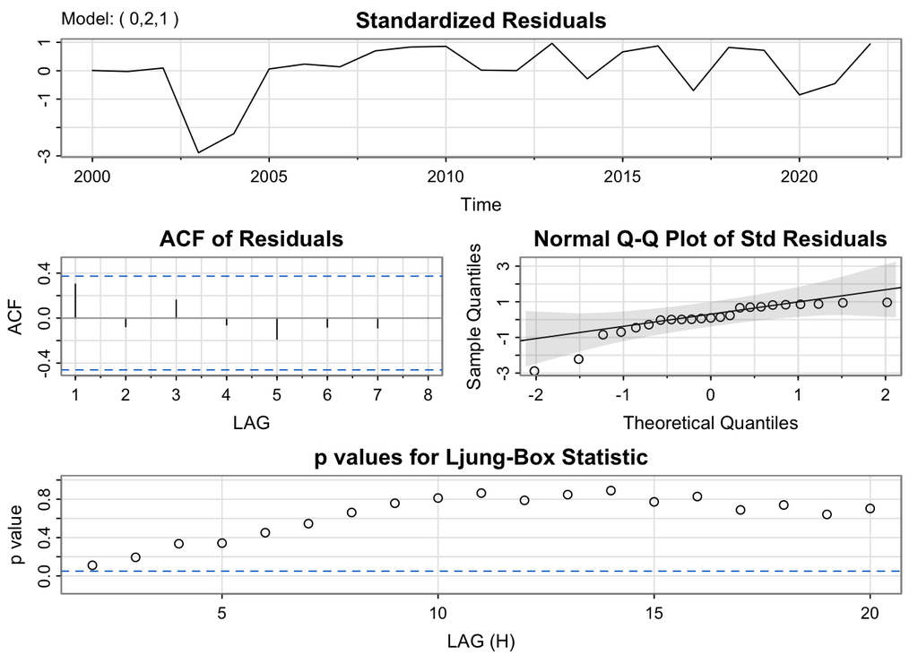

```r
model_output7_1 <- capture.output(sarima(ahs_ts,0,2,1))
```

```r
start_line <- grep("Coefficients", model_output7_1)
end_line <- length(model_output7_1)
cat(model_output7_1[start_line:end_line], sep = "\n")
```

```
Coefficients:
    Estimate    SE t.value p.value
ma1  -0.8178 0.174 -4.6986   1e-04

sigma^2 estimated as 0.1396581 on 20 degrees of freedom

AIC = 1.112399  AICc = 1.122424  BIC = 1.211877
```

### ARIMA(1,2,2)

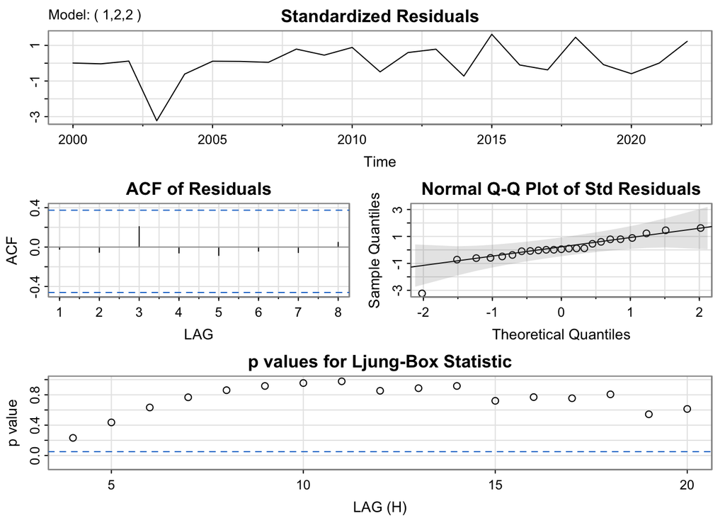

```r
model_output7_2 <- capture.output(sarima(ahs_ts,1,2,2))
```

```r
start_line <- grep("Coefficients", model_output7_2)
end_line <- length(model_output7_2)
cat(model_output7_2[start_line:end_line], sep = "\n")
```

```
Coefficients:
    Estimate     SE t.value p.value
ar1  -0.1436 0.2411 -0.5957  0.5588
ma1   0.1031 0.2008  0.5133  0.6140
ma2  -0.8969 0.1918 -4.6769  0.0002

sigma^2 estimated as 0.08092861 on 18 degrees of freedom

AIC = 0.8686595  AICc = 0.9358864  BIC = 1.067616
```

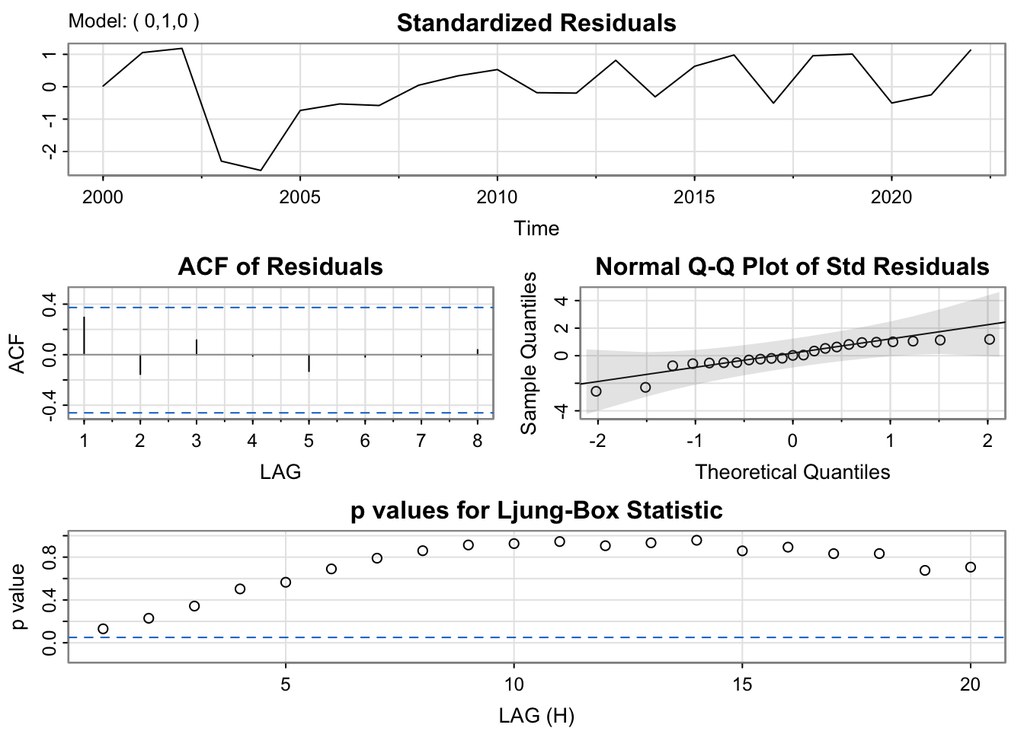

```r
model_output7_3 <- capture.output(sarima(ahs_ts,0,1,0))
```

```r
start_line <- grep("Coefficients", model_output7_3)
end_line <- length(model_output7_3)
cat(model_output7_3[start_line:end_line], sep = "\n")
```

```
Coefficients:
         Estimate     SE t.value p.value
constant  -0.1643 0.0758 -2.1668  0.0419

sigma^2 estimated as 0.1264488 on 21 degrees of freedom

AIC = 0.9517778  AICc = 0.9608687  BIC = 1.050963
```

Considering all model diagnostics and information criteria, ARIMA(1,2,2) was selected as the best-fitting model.

**S&P 500 Index**

### ARIMA(0,2,1)

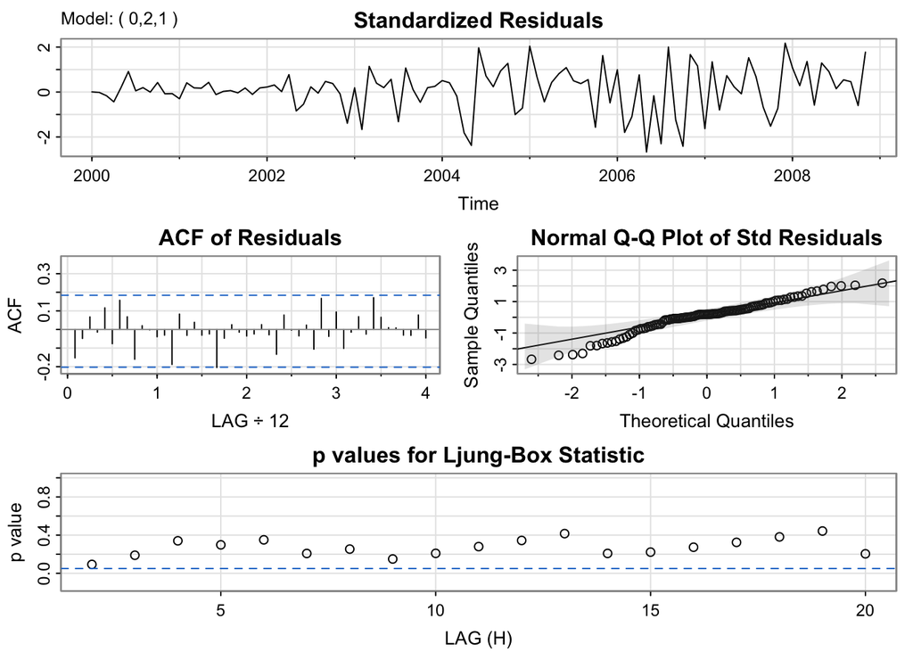

```r
model_output8_1 <- capture.output(sarima(sp500_ts,0,2,1))
```

```r
start_line <- grep("Coefficients", model_output8_1)
end_line <- length(model_output8_1)
cat(model_output8_1[start_line:end_line], sep = "\n")
```

```
Coefficients:
    Estimate     SE  t.value p.value
ma1  -0.9864 0.0499 -19.7837       0

sigma^2 estimated as 26227.73 on 104 degrees of freedom

AIC = 13.08441  AICc = 13.08478  BIC = 13.13496
```

### ARIMA(1,2,1)

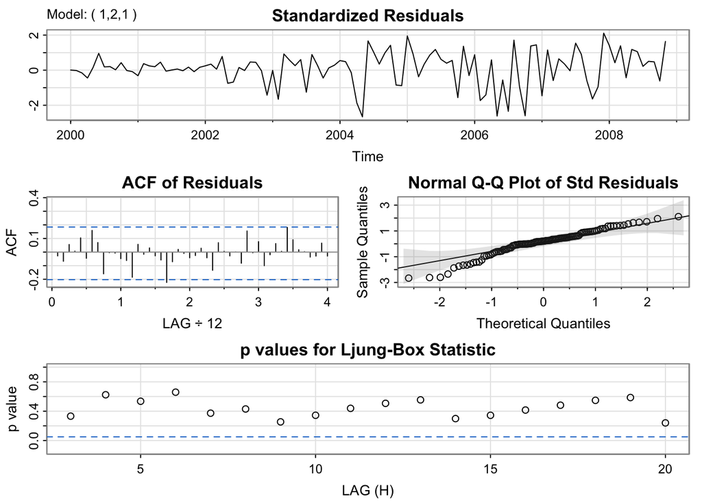

```r
model_output8_2 <- capture.output(sarima(sp500_ts,1,2,1))
```

```r
start_line <- grep("Coefficients", model_output8_2)
end_line <- length(model_output8_2)
cat(model_output8_2[start_line:end_line], sep = "\n")
```

```
Coefficients:
    Estimate     SE  t.value p.value
ar1  -0.1446 0.1004  -1.4405  0.1527
ma1  -0.9725 0.0457 -21.2881  0.0000

sigma^2 estimated as 25807.64 on 103 degrees of freedom

AIC = 13.08387  AICc = 13.08499  BIC = 13.1597
```

### ARIMA(0,1,1)

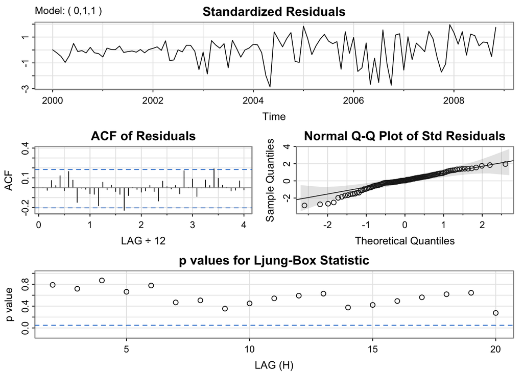

```r
model_output8_3 <- capture.output(sarima(sp500_ts,0,1,1))
```

```r
start_line <- grep("Coefficients", model_output8_3)
end_line <- length(model_output8_3)
cat(model_output8_3[start_line:end_line], sep = "\n")
```

```
Coefficients:
         Estimate      SE t.value p.value
ma1       -0.1527  0.0970 -1.5752  0.1182
constant  36.9643 13.0739  2.8273  0.0056

sigma^2 estimated as 25148.87 on 104 degrees of freedom

AIC = 13.02727  AICc = 13.02837  BIC = 13.10265
```

Considering all model diagnostics and information criteria, ARIMA(0,1,1) was selected as the best-fitting model.

**U.S. Retail & Food Services Sales**

### ARIMA(0,1,2)

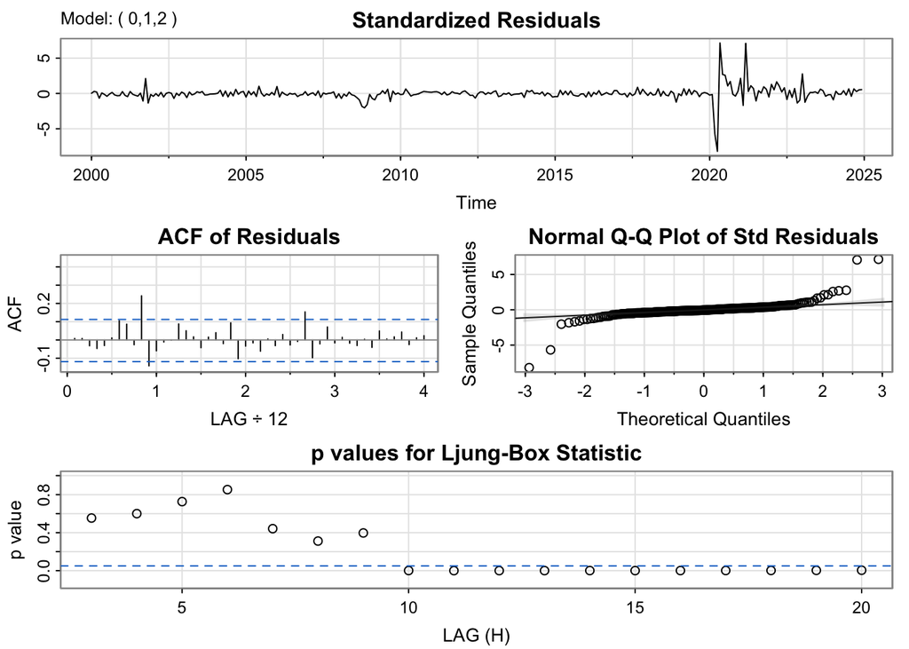

```r
model_output9_1 <- capture.output(sarima(rsafs_ts,0,1,2))
```

```r
start_line <- grep("Coefficients", model_output9_1)
end_line <- length(model_output9_1)
cat(model_output9_1[start_line:end_line], sep = "\n")
```

```
Coefficients:
          Estimate       SE t.value p.value
ma1        -0.0337   0.0563 -0.5982  0.5502
ma2        -0.2388   0.0567 -4.2137  0.0000
constant 1515.4365 364.3337  4.1595  0.0000

sigma^2 estimated as 74635672 on 296 degrees of freedom

AIC = 20.99316  AICc = 20.99343  BIC = 21.04267
```

### ARIMA(2,1,0)

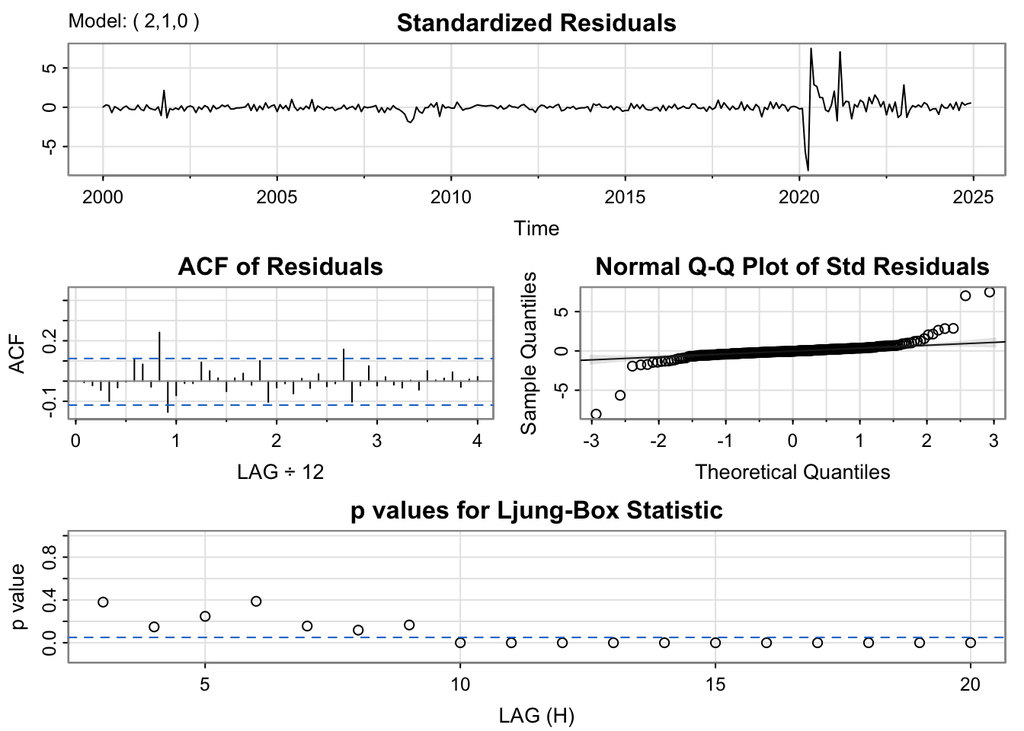

```r
model_output9_2 <- capture.output(sarima(rsafs_ts,2,1,0))
```

```r
start_line <- grep("Coefficients", model_output9_2)
end_line <- length(model_output9_2)
cat(model_output9_2[start_line:end_line], sep = "\n")
```

```
Coefficients:
          Estimate       SE t.value p.value
ar1        -0.0132   0.0565 -0.2333  0.8157
ar2        -0.2061   0.0564 -3.6526  0.0003
constant 1518.7885 411.9620  3.6867  0.0003

sigma^2 estimated as 75261997 on 296 degrees of freedom

AIC = 21.00141  AICc = 21.00168  BIC = 21.05091
```

Considering all model diagnostics and information criteria, ARIMA(0,1,2) was selected as the best-fitting model.